# SIT742 2026T2 Assignment 2 Starter Notebook: Group Forecasting Project

**Forecasting Performance Determines Your Final Grade Band**

Your Forecasting Performance Grade determines the grade band for your final A2 mark.

- **Forecasting measures:** The grade is determined primarily by MASE. MAPE is used as supporting cross-check evidence.
- **Questions Q1-Q7:** Your marks for these questions determine the exact final mark within the grade band.
- **Grade bands:** HD: 80-100; D: 70-79; C: 60-69; P: 50-59; F: 0-49.

For example, if your Forecasting Performance Grade is D, your final A2 mark will be between 70 and 79, with the exact mark determined by your marks for Questions Q1-Q7.

Complete this notebook for Assignment 2. Preserve the required headings, function names, object names, and written-answer markers.

**Required autograding markers**

Do not delete, rename, edit, move, or reorder any `A2:ANSWER` START/END marker comment. Write each response between the matching markers for that question. Changed or missing markers may prevent a response from being detected correctly during marking.

## Group Details

Complete the group details before submission. Follow the CloudDeakin Assignment requirements for peer/self-review and contribution material.

`email_username` is the part before `@deakin.edu.au`; for example, use `xyz` for `xyz@deakin.edu.au`. If your group has more or fewer than three members because of an approved arrangement, adjust the `members` list and explain this in the contribution/video evidence.

```python
GROUP_INFO = {
    "group_id": "35",
    "group_name": "Group 35",
    "members": [
        {
            "student_id": "225473555",
            "name": "Daniel Ivan Gudasic",
            "deakin_email": "s225473555@deakin.edu.au",
            "email_username": "s225473555",
            "role_or_contribution": "Q5, Q6",
        },
        {
            "student_id": "225143873",
            "name": "Keiren James Brandt-Sawdy",
            "deakin_email": "s225143873@deakin.edu.au",
            "email_username": "s225143873",
            "role_or_contribution": "Q1, Q2, Q3",
        },
        {
            "student_id": "217141208",
            "name": "Kyle King",
            "deakin_email": "s217141208@deakin.edu.au",
            "email_username": "s217141208",
            "role_or_contribution": "Q3, Q4",
        },
    ],
    "unit": "SIT742",
    "assignment": "A2",
    "teaching_period": "2026T2",
}
```

```python
A2_REQUIRED_OBJECTS = [
    "GROUP_INFO",
    "raw_tourism_data",
    "training_actual_wide_to_2023M02",
    "validation_actual_wide_2023M03_2023M07",
    "public_history_wide_to_2023M07",
    "baseline_lag1_validation_forecast_wide",
    "baseline_lag12_validation_forecast_wide",
    "baseline_lag1_validation_audit",
    "baseline_lag12_validation_audit",
    "baseline_validation_comparison",
    "baseline_validation_summary",
    "tourism_series_long",
    "modelling_data_or_feature_table",
    "external_feature_log",
    "validation_forecasts",
    "validation_metrics",
    "model_summary",
    "forecast_submission_wide",
    "forecast_submission_audit",
]

A2_REQUIRED_FUNCTIONS = [
    "generate_naive_forecast_wide",
    "validate_forecast_actual_wide",
    "evaluate_forecast_wide",
]
```

## Required scaffold names and forecasting pipeline

Do not delete or rename required functions, objects, question headings, or written-answer markers. You may add helper cells, functions, models, packages, and intermediate variables.

Key required objects:

| Name | Meaning |
| --- | --- |
| `GROUP_INFO` | Group/member metadata, including Deakin email and email username. |
| `raw_tourism_data` | Public `ISF-TDF2023` dataset loaded into Python. |
| `training_actual_wide_to_2023M02` | Training actuals up to validation cutoff `2023M02`. |
| `validation_actual_wide_2023M03_2023M07` | Visible validation actual/result table. |
| `public_history_wide_to_2023M07` | Public history available at final cutoff `2023M07`. |
| `baseline_validation_comparison` | Destination-level MAE, MASE, MAPE, denominator diagnostics, and row counts for both required baselines. |
| `baseline_validation_summary` | Aggregate validation measures for both required baselines. |
| `tourism_series_long` | Long-format DataFrame with at least `Date`, `destination`, and `demand`. |
| `modelling_data_or_feature_table` | Cutoff-safe modelling data, feature table, or concise model-ready evidence summary. |
| `external_feature_log` | Fixed-column external-source DataFrame, or a zero-row DataFrame with those columns if no external data is used. |
| `validation_forecasts` | Long-format validation forecast DataFrame using `VALIDATION_FORECAST_COLUMNS`. |
| `validation_metrics` | Destination-level validation measure DataFrame using `VALIDATION_METRIC_COLUMNS`. |
| `model_summary` | One-row-per-model DataFrame using `MODEL_SUMMARY_COLUMNS`. |
| `forecast_submission_wide` | Final 12-row all-20 destination forecast table exported directly to CSV. |
| `forecast_submission_audit` | Fixed-key Q2 forecast-only audit for the final wide forecast table. |

Pipeline: Q1 creates naive wide baselines; Q2 audits schema/alignment; Q3 calculates measures; integrated Part I evidence creates baseline tables; Q4 develops models; Q5 exports final forecasts; Q6 interprets performance and markets; Q7 demonstrates reproducibility and collaboration.

## Assignment overview

Build a reproducible forecasting workflow for the public TULIP Lab `ISF-TDF2023` tourism demand dataset. Forecast all 20 destination series for `2023M08` to `2024M07`, analyse selected markets, and submit a wide-format forecast CSV with one row per forecast month.

Assessment structure: Part I functions 15 marks, Part II forecasting project 70 marks, compulsory group video 15 marks. Any forecasting method is allowed if it is cutoff-safe, reproducible, stable enough for assessment, and interpretable.

**Reproducibility and Stability**

The notebook should rerun from a clean runtime, preserve required names, document inputs and seeds where relevant, regenerate the final CSV from `forecast_submission_wide`, and avoid local absolute paths, manual CSV edits, placeholder forecasts, or uncontrolled stochastic outputs.

Final output: `forecast_submission_wide` with one `Date` column, exactly 12 rows for `2023M08` to `2024M07`, and exactly the 20 public-dataset destination columns. Export the final CSV directly from this object with `index=False`.

Performance measures: MASE and MAPE are both required. MAE is used where needed to support MASE numerator checking. See the A2 Forecast Measures Guide for definitions and worked examples. See the A2 Function Examples Guide for detailed Q1-Q3 toy inputs, expected outputs, and function I/O examples.

## Setup and dataset loading

This section provides a Google Colab / online execution option using a public raw URL. You may add a local execution option if your group uses a cloned repository, but do not rely on absolute local paths.

```python
from pathlib import Path

import numpy as np
import pandas as pd
from statsmodels.tsa.arima.model import ARIMA

pd.set_option("display.max_columns", 40)
pd.set_option("display.width", 140)

import matplotlib.pyplot as plt
```

```python
DATA_URL = "https://raw.githubusercontent.com/tulip-lab/open-data/main/ISF-TDF2023/ISF-TDF2023.csv"

TRAIN_END = "2023M02"
VALIDATION_MONTHS = [f"2023M{month:02d}" for month in range(3, 8)]
VALIDATION_START = VALIDATION_MONTHS[0]
VALIDATION_END = VALIDATION_MONTHS[-1]
FORECAST_MONTHS = [f"2023M{month:02d}" for month in range(8, 13)] + [f"2024M{month:02d}" for month in range(1, 8)]
FORECAST_START = FORECAST_MONTHS[0]
FORECAST_END = FORECAST_MONTHS[-1]
FINAL_FORECAST_MONTHS = FORECAST_MONTHS

FOCUS_REQUIRED_DESTINATIONS = ["Australia", "Japan"]
FINAL_FORECAST_DATE_COLUMN = "Date"

Q2_AUDIT_FIELDS = [
    "is_valid",
    "can_align",
    "forecast_row_count",
    "actual_row_count",
    "expected_row_count",
    "missing_months_in_forecast",
    "missing_months_in_actual",
    "extra_months_in_forecast",
    "extra_months_in_actual_source",
    "missing_destinations_in_forecast",
    "missing_destinations_in_actual",
    "extra_columns_in_forecast",
    "duplicate_forecast_dates",
    "duplicate_actual_dates",
    "missing_forecast_value_count",
    "missing_actual_value_count",
    "nonnumeric_forecast_value_count",
    "nonnumeric_actual_value_count",
    "nonfinite_forecast_value_count",
    "nonfinite_actual_value_count",
]

DESTINATION_METRIC_COLUMNS = [
    "destination",
    "n",
    "mae",
    "mase",
    "mape",
    "denominator",
    "n_denominator_pairs",
    "mase_available",
    "denominator_warning",
]
AGGREGATE_METRIC_FIELDS = [
    "n_destinations",
    "mean_mase",
    "median_mase",
    "mean_mape",
]

EXTERNAL_FEATURE_LOG_COLUMNS = [
    "source_name",
    "source_url_or_reference",
    "local_file_or_url",
    "retrieval_date",
    "publication_or_release_date",
    "latest_observation_used",
    "cutoff_applicable",
    "features_created",
    "transformation_summary",
    "licence_or_access_notes",
]
VALIDATION_FORECAST_COLUMNS = [
    "model_label",
    "Date",
    "destination",
    "forecast",
]
VALIDATION_METRIC_COLUMNS = ["model_label"] + DESTINATION_METRIC_COLUMNS
MODEL_SUMMARY_COLUMNS = [
    "model_label",
    "model_family",
    "n_destinations",
    "mean_mase",
    "median_mase",
    "mean_mape",
    "selected",
    "selection_rationale",
    "reproducibility_notes",
    "stability_notes",
]

BASELINE_COMPARISON_COLUMNS = [
    "model_label",
    "lag",
] + DESTINATION_METRIC_COLUMNS
BASELINE_SUMMARY_COLUMNS = [
    "model_label",
    "lag",
] + AGGREGATE_METRIC_FIELDS
```

```python
# Option A: Google Colab / online execution.
raw_tourism_data = pd.read_csv(DATA_URL)

DESTINATION_COLUMNS = [column for column in raw_tourism_data.columns if column != FINAL_FORECAST_DATE_COLUMN]
FINAL_FORECAST_COLUMNS = [FINAL_FORECAST_DATE_COLUMN] + DESTINATION_COLUMNS
REQUIRED_DESTINATIONS = DESTINATION_COLUMNS

# Inspect the first few rows during your own work.
raw_tourism_data.head()
```

|  | Date | Canada | Chile | Mexico | Taiwan China | Hong Kong China | Japan | South Korea | Macao China | Maldives | Cambodia | Indonesia | Singapore | New Zealand | USA | Thailand | Turkey | Australia | Hawaii | Austria | Czech |
| --- | --- | --- | --- | --- | --- | --- | --- | --- | --- | --- | --- | --- | --- | --- | --- | --- | --- | --- | --- | --- | --- |
| 0 | 1989M01 | NaN | NaN | NaN | NaN | NaN | NaN | NaN | NaN | NaN | NaN | NaN | NaN | NaN | NaN | NaN | NaN | 1660.0 | 532.0 | NaN | NaN |
| 1 | 1989M02 | NaN | NaN | NaN | NaN | NaN | NaN | NaN | NaN | NaN | NaN | NaN | NaN | NaN | NaN | NaN | NaN | 3090.0 | 1550.0 | NaN | NaN |
| 2 | 1989M03 | NaN | NaN | NaN | NaN | NaN | NaN | NaN | NaN | NaN | NaN | NaN | NaN | NaN | NaN | NaN | NaN | 2570.0 | 822.0 | NaN | NaN |
| 3 | 1989M04 | NaN | NaN | NaN | NaN | NaN | NaN | NaN | NaN | NaN | NaN | NaN | NaN | NaN | NaN | NaN | NaN | 1580.0 | 1010.0 | NaN | NaN |
| 4 | 1989M05 | NaN | NaN | NaN | NaN | NaN | NaN | NaN | NaN | NaN | NaN | NaN | NaN | NaN | NaN | NaN | NaN | 1850.0 | 1383.0 | NaN | NaN |

### Validation and final-cutoff split objects

Create these required scaffold objects from `raw_tourism_data` using the `Date` column and the existing constants. Use a real year-month representation such as `pandas.Period(..., freq="M")`; do not filter by direct string comparison on month labels.

- `training_actual_wide_to_2023M02`: used for validation MASE denominators, validation MAPE alignment, and validation baseline generation cutoff.
- `validation_actual_wide_2023M03_2023M07`: visible validation actual/result table used for Q1-Q3 integrated evidence and Q4 validation comparison.
- `public_history_wide_to_2023M07`: public history available for the final forecasting cutoff and final MASE denominator concept; no final-evaluation actual/result values are included.

```python
training_actual_wide_to_2023M02 = None
validation_actual_wide_2023M03_2023M07 = None
public_history_wide_to_2023M07 = None

# Period-based split pattern after you confirm the Date labels and columns.
# Do not use direct string comparison for month filtering.
def month_label_to_period(month_label):
    return pd.Period(str(month_label).replace("M", "-"), freq="M")

raw_tourism_data_with_period = raw_tourism_data.copy()
raw_tourism_data_with_period["_month_period"] = raw_tourism_data_with_period[
    FINAL_FORECAST_DATE_COLUMN
].map(month_label_to_period)

month_label_to_period_example = raw_tourism_data_with_period.loc[
    raw_tourism_data_with_period["_month_period"] <= month_label_to_period(TRAIN_END),
    FINAL_FORECAST_COLUMNS,
].copy()

validation_periods = [month_label_to_period(month) for month in VALIDATION_MONTHS]
validation_actual_wide_2023M03_2023M07 = raw_tourism_data_with_period.loc[
    raw_tourism_data_with_period["_month_period"].isin(validation_periods),
    FINAL_FORECAST_COLUMNS,
].copy()

public_history_wide_to_2023M07 = raw_tourism_data_with_period.loc[
    raw_tourism_data_with_period["_month_period"] <= month_label_to_period("2023M07"),
    FINAL_FORECAST_COLUMNS,
].copy()

# The helper column _month_period is not part of the required wide tables.
```

```python
training_actual_wide_to_2023M02 = raw_tourism_data_with_period.loc[
    raw_tourism_data_with_period["_month_period"] <= month_label_to_period(TRAIN_END),
    FINAL_FORECAST_COLUMNS,
].copy()
```

## Part I: Forecast table generation and evaluation functions

Use the A2 Function Examples Guide for detailed Q1-Q3 input/output examples. Use the A2 Forecast Measures Guide for MASE/MAPE definitions and examples.

### Q1. General naive-lag forecast table generator [5 marks]

Implement `generate_naive_forecast_wide(historical_actual_wide, cutoff_label, forecast_months, required_destinations=None, lag=1, date_column="Date")`.

Requirements: accept a wide actual table; return a pandas DataFrame with exactly one row per requested month; use all destination columns when `required_destinations=None`; otherwise forecast exactly the supplied destinations; use only values available at or before `cutoff_label`; support positive integer `lag`, especially `lag=1` and `lag=12`; support arbitrary forecast months and all destinations; compute recursive lag forecasts in chronological month order; avoid string subtraction for month labels.

Return rows in the supplied `forecast_months` order. Return columns in the exact order `date_column`, followed by the inferred or supplied destination order. Do not return an index column, `model_label`, diagnostics, or other extra columns.

Lag rule: for forecast month `m`, use source month `m - lag`. If the source month is after the cutoff but has already been forecast, use that generated forecast recursively. If no source value is available, return `NaN` or raise a clear error.

**Required answer markers:** Do not delete, rename, edit, move, or reorder the Q1 START/END marker comments below. Write your response between them.

#### Optional month-label helper example

This optional helper example only shows one way to convert labels such as `2023M03` into a month-aware representation. You may implement your own helper inside Q1. Do not use string subtraction for month arithmetic.

```python
def month_label_to_period_example(month_label):
    """Optional example: convert a YYYYMmm label to a pandas monthly Period."""
    return pd.Period(str(month_label).replace("M", "-"), freq="M")


def period_to_month_label_example(period):
    """Optional example: convert a pandas monthly Period back to YYYYMmm."""
    return f"{period.year}M{period.month:02d}"
```

```python
def generate_naive_forecast_wide(
    historical_actual_wide,
    cutoff_label,
    forecast_months,
    required_destinations=None,
    lag=1,
    date_column="Date",
):
    """Return the required wide-format naive-lag forecast DataFrame.

    Return exactly one row per requested month in the supplied forecast_months
    order. Return columns as date_column followed by the inferred or supplied
    destination order, with no extra columns. If required_destinations is None,
    use all columns except date_column in historical_actual_wide.

    For each forecast month m, use m - lag months as the source month. Use
    observed values at or before cutoff_label; otherwise use previously generated
    forecasts recursively when available. Raise a clear error if lag is not a
    positive integer. Use month-aware labels, not string subtraction.
    """
    ##
    naive_forecast_wide = []

    # -----------------------------------------
    # Input Checks
    # -----------------------------------------

    #check lag is positive integer
    if not isinstance(lag, int) or lag < 1:
      raise ValueError(f'Lag value entered is {lag} with type {type(lag)}. Lag must be a positive integer')

    #sort dataframe by date
    historical_data = historical_actual_wide.sort_values(by=date_column)

    # Handle required_destinations input, checking that all destinations are actually in the dataset
    if required_destinations is None:
      required_destinations = [column for column in historical_actual_wide.columns if column != date_column]
    else:
      required_destinations = list(required_destinations)
      missing = [column for column in required_destinations if column not in historical_actual_wide.columns]
      if missing:
        raise ValueError(f"These destinations are not in the dataset: {missing}")

    # ----------------------------------------------------------------------------------
    # Build a table of values that includes only the destinations and the date specified
    # AUse this table to find the lag values, and append forecasts to it so later searches can find these values
    # ----------------------------------------------------------------------------------

    # build df with date column first, and then the destinations in the order they appear or the order they are inputted

    df_cut = historical_data.copy()
    df_cut = df_cut[
        [date_column] + required_destinations
    ]

    # remove rows after cuttoff date
    if cutoff_label is not None:
      cut_date = month_label_to_period(cutoff_label)
      dates_in_window = df_cut[date_column].map(month_label_to_period) <= cut_date
      df_cut = df_cut[dates_in_window]

    # check that cuttoff was applied correctly
      latest_month = df_cut[date_column].map(month_label_to_period).max()
      assert latest_month <= cut_date

    # make date column an index for easier lookup
    df_cut = df_cut.set_index(date_column)



    # ----------------------------------------------------------------------------------
    # Build the forecast table
    # ----------------------------------------------------------------------------------


    # loop through forcast dates, calculate lag month and lookup
    x = {}
    sorted_months = [month_label_to_period(date) for date in forecast_months]
    sorted_months.sort()
    sorted_months = [period_to_month_label_example(date) for date in sorted_months]

    for forecast_date in sorted_months:
      lag_date = month_label_to_period(forecast_date) - lag
      lag_date = period_to_month_label_example(lag_date)

    # checkif lag date exists in data
      try:
        lag_row = df_cut.loc[lag_date]

      except KeyError:
        raise ValueError(f'The Lag date {lag_date} is not in data')

    # add the forecast value to the table for future lookup
      df_cut.loc[forecast_date] = lag_row

    # build the row to append
      forecast_row = {date_column: forecast_date}
      for destination in required_destinations:
        forecast_row[destination] = lag_row[destination]

      x[forecast_date] = forecast_row


    for date in forecast_months:
      naive_forecast_wide.append(x[date])

    naive_forecast_wide = pd.DataFrame(naive_forecast_wide)
    return naive_forecast_wide
```

#### Q1 illustrative toy example only

Illustrative toy example only. Your real submission must apply the same logic to all 20 destinations and the required validation/final periods.

These toy checks are illustrative and not exhaustive. Passing these checks does not guarantee full marks; your functions must also satisfy the full assignment specification and work on the required validation and final forecast structures.

```python
q1_toy_historical_actual_wide = pd.DataFrame({
    "Date": ["2022M03", "2022M04", "2022M05", "2022M06", "2022M07", "2023M01", "2023M02"],
    "Australia": [70, 75, 80, 85, 90, 95, 100],
    "Japan": [180, 190, 200, 210, 220, 230, 240],
})

q1_expected_lag1 = pd.DataFrame({
    "Date": ["2023M03", "2023M04", "2023M05"],
    "Australia": [100, 100, 100],
    "Japan": [240, 240, 240],
})

q1_expected_lag12 = pd.DataFrame({
    "Date": ["2023M03", "2023M04", "2023M05"],
    "Australia": [70, 75, 80],
    "Japan": [180, 190, 200],
})

# After implementing generate_naive_forecast_wide, set this to True and compare
# your toy outputs with q1_expected_lag1 and q1_expected_lag12.
RUN_Q1_TOY_CHECKS = True

if RUN_Q1_TOY_CHECKS:
    q1_lag1_output = generate_naive_forecast_wide(
        q1_toy_historical_actual_wide,
        cutoff_label="2023M02",
        forecast_months=["2023M03", "2023M04", "2023M05"],
        lag=1,
    )
    q1_lag12_output = generate_naive_forecast_wide(
        q1_toy_historical_actual_wide,
        cutoff_label="2023M02",
        forecast_months=["2023M03", "2023M04", "2023M05"],
        lag=12,
    )

    pd.testing.assert_frame_equal(
        q1_lag1_output.reset_index(drop=True),
        q1_expected_lag1,
        check_dtype=False,
    )
    pd.testing.assert_frame_equal(
        q1_lag12_output.reset_index(drop=True),
        q1_expected_lag12,
        check_dtype=False,
    )
```

### Q2. Forecast and actual table validation/alignment [5 marks]

Implement `validate_forecast_actual_wide(forecast_wide_df, actual_wide_df=None, required_months=None, required_destinations=None, date_column="Date")`.

`df` means a pandas DataFrame. Both inputs use a wide table: one row per month, one `Date` column, and one numeric column per destination. This is not a long table.

Modes: forecast-only mode (`actual_wide_df=None`) checks export readiness; forecast-vs-actual mode checks whether forecast and actual/result tables can align by `Date` and destination.

Requirements: check required `Date`, months, destination columns, row counts, duplicate dates, extra rows/columns, missing values, numeric values, finite values, and alignment when actuals are supplied. If `required_destinations=None`, infer destination columns from `forecast_wide_df`, but all-20 evidence must still match `REQUIRED_DESTINATIONS`.

Return a Python dictionary containing every key in `Q2_AUDIT_FIELDS`, in that order. In forecast-only mode, `can_align` and all actual-related fields must be `None`, not omitted. In forecast-vs-actual mode, `actual_row_count` counts actual rows after subsetting to `required_months`; `can_align` reports structural alignment; `is_valid` reports all applicable structure and value-quality checks. Duplicate counts count occurrences after the first occurrence.

**Required answer markers:** Do not delete, rename, edit, move, or reorder the Q2 START/END marker comments below. Write your response between them.

```python
def validate_forecast_actual_wide(
    forecast_wide_df,
    actual_wide_df=None,
    required_months=None,
    required_destinations=None,
    date_column="Date",
):
    """Return the fixed Q2 audit dictionary for wide-table validation.

    Populate every key in Q2_AUDIT_FIELDS. Forecast-only mode uses None for
    can_align and every actual-related field. Forecast-vs-actual mode subsets
    actual_wide_df to required_months before reporting actual_row_count and
    checking structural alignment.
    """
    audit = {
        "is_valid": False,
        "can_align": None if actual_wide_df is None else False,
        "forecast_row_count": len(forecast_wide_df),
        "actual_row_count": None,
        "expected_row_count": (
            len(required_months) if required_months is not None else None
        ),
        "missing_months_in_forecast": [],
        "missing_months_in_actual": None,
        "extra_months_in_forecast": [],
        "extra_months_in_actual_source": None,
        "missing_destinations_in_forecast": [],
        "missing_destinations_in_actual": None,
        "extra_columns_in_forecast": [],
        "duplicate_forecast_dates": 0,
        "duplicate_actual_dates": None,
        "missing_forecast_value_count": 0,
        "missing_actual_value_count": None,
        "nonnumeric_forecast_value_count": 0,
        "nonnumeric_actual_value_count": None,
        "nonfinite_forecast_value_count": 0,
        "nonfinite_actual_value_count": None,
    }

    # --------------------------
    # Infer destination columns and months
    # --------------------------

    if required_destinations is None:
      required_destinations = [column for column in forecast_wide_df.columns if column != date_column]

    if required_months is None:
      required_months = [column for column in forecast_wide_df[date_column]]



    # --------------------------
    # row counts
    # --------------------------

    if actual_wide_df is not None:

      required_mask = actual_wide_df[date_column].isin(required_months)
      audit["actual_row_count"] = len(actual_wide_df[required_mask])

    # --------------------------
    # Missing months
    # --------------------------
    audit["missing_months_in_forecast"] = [missing for missing in required_months
                                            if missing not in forecast_wide_df[date_column].to_list()]

    if actual_wide_df is not None:
      audit["missing_months_in_actual"] = [missing for missing in required_months
                                            if missing not in actual_wide_df[date_column].to_list()]

    # --------------------------
    # Extra months
    # --------------------------
    audit["extra_months_in_forecast"] = [extra for extra in forecast_wide_df[date_column]
                                          if extra not in required_months]
    if actual_wide_df is not None:
      audit["extra_months_in_actual_source"] = [extra for extra in actual_wide_df[date_column]
                                          if extra not in required_months]

    # --------------------------
    # Missing destinations
    # --------------------------

    forecast_destinations = forecast_wide_df.columns.drop(date_column)
    audit["missing_destinations_in_forecast"] = [destination for destination in required_destinations
                                                  if destination not in forecast_destinations]

    if actual_wide_df is not None:
      actual_destinations = actual_wide_df.columns.drop(date_column)
      audit["missing_destinations_in_actual"] = [destination for destination in required_destinations
                                                  if destination not in actual_destinations]
    # --------------------------
    # Extra columns in forecast
    # --------------------------

    audit["extra_columns_in_forecast"] = [extra for extra in forecast_wide_df.columns.drop(date_column)
                                          if extra not in required_destinations]


    # --------------------------
    # Duplicates, Missing, Inf
    # --------------------------

    audit["duplicate_forecast_dates"] = int(forecast_wide_df.duplicated(subset=[date_column]).sum())
    if actual_wide_df is not None:
      audit["duplicate_actual_dates"] = int(actual_wide_df.duplicated(subset=[date_column]).sum())

    # --------------------------
    # Missing Values
    # --------------------------

    drop_cols = [extra for extra in forecast_wide_df.columns.drop(date_column)
                  if extra not in required_destinations]

    forecast_cut = forecast_wide_df.drop(columns=drop_cols)
    forecast_cut = forecast_cut[forecast_cut[date_column].isin(required_months)]
    forecast_cut = forecast_cut.drop(columns=[date_column])


    audit["missing_forecast_value_count"] = int(forecast_cut.isna().sum().sum())

    if actual_wide_df is not None:
      drop_cols = [extra for extra in forecast_wide_df.columns.drop(date_column)
        if extra not in required_destinations]
      actual_cut = actual_wide_df.drop(columns=drop_cols)
      actual_cut = actual_cut[actual_cut[date_column].isin(required_months)]
      actual_cut = actual_cut.drop(columns=[date_column])
      audit["missing_actual_value_count"] = int(actual_cut.isna().sum().sum())

    # --------------------------
    # Non-numeric Values
    # --------------------------

    audit["nonnumeric_forecast_value_count"] = int(forecast_cut.apply(
        lambda x: (x.notnull() & pd.to_numeric(x, errors='coerce')
        .isnull())
        .sum()).sum())

    if actual_wide_df is not None:
        audit["nonnumeric_actual_value_count"] = int(actual_cut.apply(
        lambda x: (x.notnull() & pd.to_numeric(x, errors='coerce')
        .isnull())
        .sum()).sum())

    # --------------------------
    # Non-finite value
    # --------------------------

    forecast_numeric = forecast_cut.apply(pd.to_numeric, errors="coerce")
    audit["nonfinite_forecast_value_count"] = int(np.isinf(forecast_numeric).sum().sum())

    if actual_wide_df is not None:
      actual_numeric = actual_cut.apply(pd.to_numeric, errors="coerce")
      audit["nonfinite_actual_value_count"] = int(np.isinf(actual_numeric).sum().sum())


    # --------------------------
    # can align
    # --------------------------


    if actual_wide_df is None:
      audit["can_align"] = None
    else:
      audit["can_align"] = all([
          audit["missing_months_in_forecast"] == [],
          audit["missing_months_in_actual"] == [],
          audit["missing_destinations_in_forecast"] == [],
          audit["missing_destinations_in_actual"] == [],
          audit["duplicate_forecast_dates"] == 0,
          audit["duplicate_actual_dates"] == 0
          ]
      )

    # --------------------------
    # is valid
    # --------------------------

    audit["is_valid"] = all([
        date_column in forecast_wide_df.columns,
        audit["can_align"] is not False,
        audit["duplicate_forecast_dates"] == 0,
        audit["actual_row_count"] == audit["expected_row_count"] if actual_wide_df is not None else True,
        audit["missing_months_in_forecast"] == [],
        audit["missing_months_in_actual"] == [] if actual_wide_df is not None else True,
        audit["extra_months_in_forecast"] == [],
        audit["missing_destinations_in_forecast"] == [],
        audit["extra_columns_in_forecast"] == [],
        audit["missing_forecast_value_count"] == 0,
        audit["missing_actual_value_count"] == 0 if actual_wide_df is not None else True,
        audit["nonnumeric_forecast_value_count"] == 0,
        audit["nonnumeric_actual_value_count"] == 0 if actual_wide_df is not None else True,
        audit["nonfinite_forecast_value_count"] == 0,
        audit["nonfinite_actual_value_count"] == 0 if actual_wide_df is not None else True,
    ])


# The audit should show is_valid=True, correct row counts, no missing months, no missing destinations, no duplicate dates, and numeric finite
# values.
    return audit
```

#### Q2 illustrative toy examples only

Illustrative toy examples only. Your real submission must apply the same logic to all 20 destinations and the required validation/final periods.

The examples check the fixed dictionary schema in forecast-only and forecast-vs-actual modes. They are not exhaustive; your function must still satisfy the full assignment specification.

```python
q2_valid_forecast_wide_df = pd.DataFrame({
    "Date": ["2023M08", "2023M09"],
    "Australia": [12345.0, 12400.0],
    "Japan": [23456.0, 23500.0],
})

q2_bad_forecast_wide_df = pd.DataFrame({
    "Date": ["2023M08", "2023M08"],
    "Australia": [12345.0, "not_a_number"],
})

q2_actual_source_wide_df = pd.DataFrame({
    "Date": ["2023M07", "2023M08", "2023M09"],
    "Australia": [12200.0, 12350.0, 12420.0],
    "Japan": [23200.0, 23480.0, 23540.0],
})

q2_required_months = ["2023M08", "2023M09"]
q2_required_destinations = ["Australia", "Japan"]

q2_expected_valid_forecast_only_audit = {
    "is_valid": True,
    "can_align": None,
    "forecast_row_count": 2,
    "actual_row_count": None,
    "expected_row_count": 2,
    "missing_months_in_forecast": [],
    "missing_months_in_actual": None,
    "extra_months_in_forecast": [],
    "extra_months_in_actual_source": None,
    "missing_destinations_in_forecast": [],
    "missing_destinations_in_actual": None,
    "extra_columns_in_forecast": [],
    "duplicate_forecast_dates": 0,
    "duplicate_actual_dates": None,
    "missing_forecast_value_count": 0,
    "missing_actual_value_count": None,
    "nonnumeric_forecast_value_count": 0,
    "nonnumeric_actual_value_count": None,
    "nonfinite_forecast_value_count": 0,
    "nonfinite_actual_value_count": None,
}

q2_expected_invalid_forecast_only_audit = {
    "is_valid": False,
    "can_align": None,
    "forecast_row_count": 2,
    "actual_row_count": None,
    "expected_row_count": 2,
    "missing_months_in_forecast": ["2023M09"],
    "missing_months_in_actual": None,
    "extra_months_in_forecast": [],
    "extra_months_in_actual_source": None,
    "missing_destinations_in_forecast": ["Japan"],
    "missing_destinations_in_actual": None,
    "extra_columns_in_forecast": [],
    "duplicate_forecast_dates": 1,
    "duplicate_actual_dates": None,
    "missing_forecast_value_count": 0,
    "missing_actual_value_count": None,
    "nonnumeric_forecast_value_count": 1,
    "nonnumeric_actual_value_count": None,
    "nonfinite_forecast_value_count": 0,
    "nonfinite_actual_value_count": None,
}

q2_expected_valid_alignment_audit = {
    "is_valid": True,
    "can_align": True,
    "forecast_row_count": 2,
    "actual_row_count": 2,
    "expected_row_count": 2,
    "missing_months_in_forecast": [],
    "missing_months_in_actual": [],
    "extra_months_in_forecast": [],
    "extra_months_in_actual_source": ["2023M07"],
    "missing_destinations_in_forecast": [],
    "missing_destinations_in_actual": [],
    "extra_columns_in_forecast": [],
    "duplicate_forecast_dates": 0,
    "duplicate_actual_dates": 0,
    "missing_forecast_value_count": 0,
    "missing_actual_value_count": 0,
    "nonnumeric_forecast_value_count": 0,
    "nonnumeric_actual_value_count": 0,
    "nonfinite_forecast_value_count": 0,
    "nonfinite_actual_value_count": 0,
}

# After implementing validate_forecast_actual_wide, set this to True.
RUN_Q2_TOY_CHECKS = True

if RUN_Q2_TOY_CHECKS:
    q2_valid_forecast_only_audit = validate_forecast_actual_wide(
        q2_valid_forecast_wide_df,
        actual_wide_df=None,
        required_months=q2_required_months,
        required_destinations=q2_required_destinations,
    )
    q2_invalid_forecast_only_audit = validate_forecast_actual_wide(
        q2_bad_forecast_wide_df,
        actual_wide_df=None,
        required_months=q2_required_months,
        required_destinations=q2_required_destinations,
    )
    q2_valid_alignment_audit = validate_forecast_actual_wide(
        q2_valid_forecast_wide_df,
        actual_wide_df=q2_actual_source_wide_df,
        required_months=q2_required_months,
        required_destinations=q2_required_destinations,
    )

    q2_toy_pairs = [
        (q2_valid_forecast_only_audit, q2_expected_valid_forecast_only_audit),
        (q2_invalid_forecast_only_audit, q2_expected_invalid_forecast_only_audit),
        (q2_valid_alignment_audit, q2_expected_valid_alignment_audit),
    ]
    for observed_audit, expected_audit in q2_toy_pairs:
        assert isinstance(observed_audit, dict)
        assert list(observed_audit) == Q2_AUDIT_FIELDS
        assert observed_audit == expected_audit
```

### Q3. Forecast accuracy measures from forecast and actual tables [5 marks]

Implement `evaluate_forecast_wide(forecast_wide_df, actual_wide_df, training_actual_wide_df, start_month, end_month, required_destinations=None, naive_lag=1, date_column="Date")`.

Use the A2 Forecast Measures Guide. Both MASE and MAPE are required.

Requirements: align forecast and actual/result tables by `Date` and destination; work destination by destination; select months from `start_month` to `end_month`; evaluate all forecast destination columns when `required_destinations=None`; compute MAE, MASE, MAPE, denominator, `n`, `n_denominator_pairs`, `mase_available`, and `denominator_warning`; keep MASE/MAPE separately identifiable; sort training actuals chronologically; use all valid lagged training pairs for each destination's MASE denominator; use `naive_lag=1` for official validation unless stated otherwise; handle missing values, nonfinite values, zero actuals for MAPE, and unavailable denominators explicitly.

Return exactly `(destination_metrics, aggregate_metrics)`. `destination_metrics` must be a pandas DataFrame with columns in `DESTINATION_METRIC_COLUMNS`. `aggregate_metrics` must be a Python dictionary with exactly the keys in `AGGREGATE_METRIC_FIELDS`.

Do not fill missing denominators with zero. Do not use validation actuals or assessment-period actual/result values to repair denominators. `lag=12` baseline forecasts are for comparison; they are not the official MASE denominator. Aggregate measures are unweighted summaries of destination-level measures unless otherwise stated.

**Required answer markers:** Do not delete, rename, edit, move, or reorder the Q3 START/END marker comments below. Write your response between them.

```python
def evaluate_forecast_wide(
    forecast_wide_df,
    actual_wide_df,
    training_actual_wide_df,
    start_month,
    end_month,
    required_destinations=None,
    naive_lag=1,
    date_column="Date",
):
    """Return (destination_metrics, aggregate_metrics).

    destination_metrics is a DataFrame using DESTINATION_METRIC_COLUMNS.
    aggregate_metrics is a dictionary using AGGREGATE_METRIC_FIELDS.
    Sort training_actual_wide_df chronologically before computing all valid
    denominator pairs. If required_destinations is None, evaluate all forecast
    columns except date_column; otherwise evaluate exactly those destinations.
    """
    destination_metrics = pd.DataFrame(columns=DESTINATION_METRIC_COLUMNS)
    aggregate_metrics = {
        field: None for field in AGGREGATE_METRIC_FIELDS
    }



    # -----------------------------
    # destinations
    # -----------------------------

    if required_destinations is None:
        destinations = [c for c in forecast_wide_df.columns if c != date_column]
    else:
        destinations = list(required_destinations)

    # -----------------------------
    # evaluation month range
    # -----------------------------

    start_period = month_label_to_period(start_month)
    end_period = month_label_to_period(end_month)

    # -----------------------------
    # select forecast and actual
    # -----------------------------

    forecast = forecast_wide_df[[date_column] + destinations].copy()
    actual = actual_wide_df[[date_column] + destinations].copy()

    forecast["_period"] = forecast[date_column].map(month_label_to_period)
    actual["_period"] = actual[date_column].map(month_label_to_period)

    forecast = forecast[forecast["_period"].between(start_period, end_period)]
    actual = actual[actual["_period"].between(start_period, end_period)]

    # sort chronologically
    forecast = forecast.sort_values("_period")
    actual = actual.sort_values("_period")

    # align forecast and actual by Date
    forecast = forecast.set_index(date_column)
    actual = actual.set_index(date_column)

    common_dates = forecast.index.intersection(actual.index)

    forecast = forecast.loc[common_dates]
    actual = actual.loc[common_dates]

    # -----------------------------
    # sort training history
    # -----------------------------

    training = training_actual_wide_df[[date_column] + destinations].copy()
    training["_period"] = training[date_column].map(month_label_to_period)
    training = training.sort_values("_period")

    # -----------------------------
    # calculate destination metrics
    # -----------------------------

    rows = []

    for destination in destinations:

        f = pd.to_numeric(forecast[destination], errors="coerce")
        a = pd.to_numeric(actual[destination], errors="coerce")

        # valid forecast/actual pairs
        valid = f.notna() & a.notna() & np.isfinite(f) & np.isfinite(a)

        f_valid = f[valid]
        a_valid = a[valid]
        n = len(f_valid)

        # -------------------------
        # MAE
        # -------------------------

        mae = float(np.abs(a_valid - f_valid).mean()) if n else np.nan

        # -------------------------
        # MAPE
        # -------------------------
        # Zero actual values are excluded.

        mape_valid = valid & a.ne(0)

        if mape_valid.any():
            mape = float(
                (np.abs((a[mape_valid] - f[mape_valid]) / a[mape_valid]) * 100).mean()
            )
        else:
            mape = np.nan

        # -------------------------
        # MASE denominator
        # -------------------------
        # use all valid lagged training pairs.

        training_values = pd.to_numeric(
            training[destination], errors="coerce"
        ).to_numpy(dtype=float)

        if len(training_values) > naive_lag:
            current = training_values[naive_lag:]
            previous = training_values[:-naive_lag]

            valid_pairs = np.isfinite(current) & np.isfinite(previous)
            denominator_errors = np.abs(current[valid_pairs] - previous[valid_pairs])
        else:
            denominator_errors = np.array([], dtype=float)

        n_denominator_pairs = len(denominator_errors)

        denominator = (
            float(denominator_errors.mean())
            if n_denominator_pairs
            else np.nan
        )

        # -------------------------
        # MASE
        # -------------------------

        mase_available = (
            n > 0
            and np.isfinite(mae)
            and n_denominator_pairs > 0
            and np.isfinite(denominator)
            and denominator > 0
        )

        if mase_available:
            mase = float(mae / denominator)
            denominator_warning = False
        else:
            mase = np.nan
            denominator_warning = True

        # -------------------------
        # store destination metrics
        # -------------------------

        rows.append({
            "destination": destination,
            "n": int(n),
            "mae": mae,
            "mase": mase,
            "mape": mape,
            "denominator": denominator,
            "n_denominator_pairs": int(n_denominator_pairs),
            "mase_available": bool(mase_available),
            "denominator_warning": bool(denominator_warning)
        })

    # -----------------------------
    # destination metrics
    # -----------------------------

    destination_metrics = pd.DataFrame(
        rows, columns=DESTINATION_METRIC_COLUMNS
    )

    # -----------------------------
    # aggregate metrics
    # -----------------------------

    mase_values = destination_metrics["mase"].dropna()
    mape_values = destination_metrics["mape"].dropna()

    aggregate_metrics = {
        "n_destinations": len(destination_metrics),
        "mean_mase": float(mase_values.mean()) if len(mase_values) else np.nan,
        "median_mase": float(mase_values.median()) if len(mase_values) else np.nan,
        "mean_mape": float(mape_values.mean()) if len(mape_values) else np.nan
    }

    return destination_metrics, aggregate_metrics
```

#### Q3 illustrative toy example only

Illustrative toy example only. Your real submission must apply the same logic to all 20 destinations and the required validation/final periods.

These toy checks are illustrative and not exhaustive. Passing these checks does not guarantee full marks; your functions must also satisfy the full assignment specification and work on the required validation and final forecast structures.

Expected approximate values for this toy example: Australia MASE approximately 2.67 and MAPE 16.08%, Japan MASE = 1.00 and MAPE 8.63%, aggregate mean MASE approximately 1.83, and aggregate mean MAPE approximately 12.36%. Calculate aggregates from unrounded destination-level values, then round only for display.

```python
q3_toy_validation_forecast_wide = pd.DataFrame({
    "Date": ["2023M03", "2023M04"],
    "Australia": [100, 100],
    "Japan": [200, 220],
})

q3_toy_validation_actual_wide = pd.DataFrame({
    "Date": ["2023M03", "2023M04"],
    "Australia": [110, 130],
    "Japan": [190, 250],
})

q3_toy_training_actual_wide = pd.DataFrame({
    "Date": ["2022M12", "2023M01", "2023M02"],
    "Australia": [95, 105, 100],
    "Japan": [180, 210, 200],
})

q3_expected_destination_metrics = pd.DataFrame({
    "destination": ["Australia", "Japan"],
    "n": [2, 2],
    "mae": [20.0, 20.0],
    "mase": [2.67, 1.00],
    "mape": [16.08, 8.63],
    "denominator": [7.5, 20.0],
    "n_denominator_pairs": [2, 2],
    "mase_available": [True, True],
    "denominator_warning": [False, False],
})

q3_expected_aggregate_metrics = {
    "n_destinations": 2,
    "mean_mase": 1.83,
    "median_mase": 1.83,
    "mean_mape": 12.36,
}

q3_missing_denominator_training_actual = pd.DataFrame({
    "Date": ["2022M10", "2022M11", "2022M12", "2023M01", "2023M02"],
    "Australia": [80, np.nan, 95, 105, 100],
})

# The toy training table has three rows, so its denominator has two valid lag-1
# pairs. In the real assignment, use all valid lagged pairs available up to the
# relevant cutoff; do not truncate the window to the forecast-horizon length.
#
# For q3_missing_denominator_training_actual, valid lag-1 pairs are
# 2023M01-2022M12 and 2023M02-2023M01, so n_denominator_pairs should be 2.
#
# After implementing evaluate_forecast_wide, set this to True.
RUN_Q3_TOY_CHECKS = True

if RUN_Q3_TOY_CHECKS:
    q3_toy_destination_metrics, q3_toy_aggregate_metrics = evaluate_forecast_wide(
        q3_toy_validation_forecast_wide,
        q3_toy_validation_actual_wide,
        q3_toy_training_actual_wide,
        start_month="2023M03",
        end_month="2023M04",
        naive_lag=1,
    )

    assert isinstance(q3_toy_destination_metrics, pd.DataFrame)
    assert list(q3_toy_destination_metrics.columns) == DESTINATION_METRIC_COLUMNS
    assert isinstance(q3_toy_aggregate_metrics, dict)
    assert list(q3_toy_aggregate_metrics) == AGGREGATE_METRIC_FIELDS
    assert list(q3_toy_destination_metrics["destination"]) == ["Australia", "Japan"]
    for column in ["mae", "mase", "mape", "denominator"]:
        assert np.allclose(
            q3_toy_destination_metrics[column],
            q3_expected_destination_metrics[column],
            rtol=0.01,
            atol=0.01,
        )
    for field, expected_value in q3_expected_aggregate_metrics.items():
        assert np.isclose(q3_toy_aggregate_metrics[field], expected_value, atol=0.01)
```

### Part I integrated evidence

Use Q1-Q3 together to create `baseline_validation_comparison` and `baseline_validation_summary` for both `naive_lag1` and `naive_lag12` over validation months `2023M03` to `2023M07` for all 20 destinations.

Integrated evidence does not carry separate marks. It shows that Q1-Q3 work together and provides baseline evidence required for Q4.

Use `evaluate_forecast_wide(..., naive_lag=1)` for official MASE denominator scaling for both baselines. The `lag` column describes forecast generation, not the denominator used for official MASE.

`baseline_validation_comparison` must include `model_label`, `lag`, `destination`, `n`, `mae`, `mase`, `mape`, `denominator`, `n_denominator_pairs`, `mase_available`, and `denominator_warning`.

`baseline_validation_summary` must include `model_label`, `lag`, `n_destinations`, `mean_mase`, `median_mase`, and `mean_mape`.

Both tables must be visible in the notebook and exported PDF.

```python
# Part I integrated evidence workflow skeleton.
# 1. create training and validation actual tables
training_actual_wide_to_2023M02 = raw_tourism_data[raw_tourism_data["Date"].map(month_label_to_period) <= month_label_to_period(TRAIN_END)].copy()

validation_actual_wide_2023M03_2023M07 = raw_tourism_data[raw_tourism_data["Date"].isin(VALIDATION_MONTHS)].copy()

# 2. generate lag-1 baseline forecast
baseline_lag1_validation_forecast_wide = generate_naive_forecast_wide(training_actual_wide_to_2023M02, TRAIN_END, VALIDATION_MONTHS, lag=1)

# 3. generate lag-12 baseline forecast
baseline_lag12_validation_forecast_wide = generate_naive_forecast_wide(training_actual_wide_to_2023M02, TRAIN_END, VALIDATION_MONTHS, lag=12)

# 4. audit both baselines against validation actuals
baseline_lag1_validation_audit = validate_forecast_actual_wide(baseline_lag1_validation_forecast_wide,validation_actual_wide_2023M03_2023M07,required_months=VALIDATION_MONTHS)

baseline_lag12_validation_audit = validate_forecast_actual_wide(baseline_lag12_validation_forecast_wide, validation_actual_wide_2023M03_2023M07, required_months=VALIDATION_MONTHS)

# 5. evaluate both baselines using lag-1 MASE scaling
lag1_metrics, lag1_aggregate = evaluate_forecast_wide( baseline_lag1_validation_forecast_wide, validation_actual_wide_2023M03_2023M07, training_actual_wide_to_2023M02, VALIDATION_START, VALIDATION_END, naive_lag=1)

lag12_metrics, lag12_aggregate = evaluate_forecast_wide( baseline_lag12_validation_forecast_wide, validation_actual_wide_2023M03_2023M07, training_actual_wide_to_2023M02, VALIDATION_START, VALIDATION_END, naive_lag=1)

# 6. combine destination-level results
baseline_validation_comparison = pd.concat([ lag1_metrics.assign(model_label="naive_lag1", lag=1), lag12_metrics.assign(model_label="naive_lag12", lag=12)], ignore_index=True)[BASELINE_COMPARISON_COLUMNS]

# 7. aggregate baseline summary
baseline_validation_summary = pd.DataFrame([ {"model_label": "naive_lag1", "lag": 1, **lag1_aggregate}, {"model_label": "naive_lag12", "lag": 12, **lag12_aggregate}])[BASELINE_SUMMARY_COLUMNS]

# integrated evidence
display(baseline_lag1_validation_audit)
display(baseline_lag12_validation_audit)
display(baseline_validation_comparison)
display(baseline_validation_summary)
```

```
{'is_valid': True,
 'can_align': True,
 'forecast_row_count': 5,
 'actual_row_count': 5,
 'expected_row_count': 5,
 'missing_months_in_forecast': [],
 'missing_months_in_actual': [],
 'extra_months_in_forecast': [],
 'extra_months_in_actual_source': [],
 'missing_destinations_in_forecast': [],
 'missing_destinations_in_actual': [],
 'extra_columns_in_forecast': [],
 'duplicate_forecast_dates': 0,
 'duplicate_actual_dates': 0,
 'missing_forecast_value_count': 0,
 'missing_actual_value_count': 0,
 'nonnumeric_forecast_value_count': 0,
 'nonnumeric_actual_value_count': 0,
 'nonfinite_forecast_value_count': 0,
 'nonfinite_actual_value_count': 0}
```

```
{'is_valid': True,
 'can_align': True,
 'forecast_row_count': 5,
 'actual_row_count': 5,
 'expected_row_count': 5,
 'missing_months_in_forecast': [],
 'missing_months_in_actual': [],
 'extra_months_in_forecast': [],
 'extra_months_in_actual_source': [],
 'missing_destinations_in_forecast': [],
 'missing_destinations_in_actual': [],
 'extra_columns_in_forecast': [],
 'duplicate_forecast_dates': 0,
 'duplicate_actual_dates': 0,
 'missing_forecast_value_count': 0,
 'missing_actual_value_count': 0,
 'nonnumeric_forecast_value_count': 0,
 'nonnumeric_actual_value_count': 0,
 'nonfinite_forecast_value_count': 0,
 'nonfinite_actual_value_count': 0}
```

|  | model_label | lag | destination | n | mae | mase | mape | denominator | n_denominator_pairs | mase_available | denominator_warning |
| --- | --- | --- | --- | --- | --- | --- | --- | --- | --- | --- | --- |
| 0 | naive_lag1 | 1 | Canada | 5 | 8453.4 | 1.353923 | 44.825228 | 6243.636364 | 253 | True | False |
| 1 | naive_lag1 | 1 | Chile | 5 | 397.6 | 1.396451 | 27.106541 | 284.721739 | 115 | True | False |
| 2 | naive_lag1 | 1 | Mexico | 5 | 2637.8 | 1.654912 | 21.466003 | 1593.921659 | 217 | True | False |
| 3 | naive_lag1 | 1 | Taiwan China | 5 | 6878.6 | 0.280336 | 37.065578 | 24537.011429 | 175 | True | False |
| 4 | naive_lag1 | 1 | Hong Kong China | 5 | 1229352.2 | 5.208431 | 51.651148 | 236031.183391 | 289 | True | False |
| 5 | naive_lag1 | 1 | Japan | 5 | 131881.2 | 4.753255 | 72.586105 | 27745.450479 | 313 | True | False |
| 6 | naive_lag1 | 1 | South Korea | 5 | 94189.6 | 3.470045 | 62.132621 | 27143.627907 | 301 | True | False |
| 7 | naive_lag1 | 1 | Macao China | 5 | 487783.0 | 3.763461 | 31.331510 | 129610.207612 | 289 | True | False |
| 8 | naive_lag1 | 1 | Maldives | 5 | 12187.8 | 4.583150 | 68.842709 | 2659.262626 | 297 | True | False |
| 9 | naive_lag1 | 1 | Cambodia | 5 | 6644.4 | 1.097318 | 15.168992 | 6055.124481 | 241 | True | False |
| 10 | naive_lag1 | 1 | Indonesia | 5 | 27795.8 | 1.725403 | 41.802667 | 16109.743802 | 121 | True | False |
| 11 | naive_lag1 | 1 | Singapore | 5 | 83069.4 | 3.227311 | 63.955551 | 25739.505929 | 253 | True | False |
| 12 | naive_lag1 | 1 | New Zealand | 5 | 6087.6 | 1.665057 | 55.811792 | 3656.090909 | 253 | True | False |
| 13 | naive_lag1 | 1 | USA | 5 | 53294.6 | 2.082986 | 54.849355 | 25585.675090 | 277 | True | False |
| 14 | naive_lag1 | 1 | Thailand | 5 | 165530.6 | 4.638099 | 50.509914 | 35689.321212 | 330 | True | False |
| 15 | naive_lag1 | 1 | Turkey | 5 | 10355.8 | 7.595587 | 51.631780 | 1363.396923 | 325 | True | False |
| 16 | naive_lag1 | 1 | Australia | 5 | 14396.0 | 1.667341 | 31.963742 | 8634.107579 | 409 | True | False |
| 17 | naive_lag1 | 1 | Hawaii | 5 | 696.2 | 0.558009 | 59.127208 | 1247.650367 | 409 | True | False |
| 18 | naive_lag1 | 1 | Austria | 5 | 10319.4 | 1.578013 | 64.816447 | 6539.489451 | 237 | True | False |
| 19 | naive_lag1 | 1 | Czech | 5 | 8428.4 | 1.114481 | 54.508002 | 7562.624060 | 133 | True | False |
| 20 | naive_lag12 | 12 | Canada | 5 | 12072.2 | 1.933521 | 72.313340 | 6243.636364 | 253 | True | False |
| 21 | naive_lag12 | 12 | Chile | 5 | 1022.6 | 3.591577 | 70.906929 | 284.721739 | 115 | True | False |
| 22 | naive_lag12 | 12 | Mexico | 5 | 5456.4 | 3.423255 | 45.285123 | 1593.921659 | 217 | True | False |
| 23 | naive_lag12 | 12 | Taiwan China | 5 | 15136.6 | 0.616888 | 93.100343 | 24537.011429 | 175 | True | False |
| 24 | naive_lag12 | 12 | Hong Kong China | 5 | 2320349.4 | 9.830690 | 99.235183 | 236031.183391 | 289 | True | False |
| 25 | naive_lag12 | 12 | Japan | 5 | 152226.6 | 5.486543 | 88.305961 | 27745.450479 | 313 | True | False |
| 26 | naive_lag12 | 12 | South Korea | 5 | 126702.2 | 4.667843 | 89.190610 | 27143.627907 | 301 | True | False |
| 27 | naive_lag12 | 12 | Macao China | 5 | 1114549.8 | 8.599244 | 72.697869 | 129610.207612 | 289 | True | False |
| 28 | naive_lag12 | 12 | Maldives | 5 | 15574.8 | 5.856812 | 94.629392 | 2659.262626 | 297 | True | False |
| 29 | naive_lag12 | 12 | Cambodia | 5 | 40626.2 | 6.709391 | 84.627387 | 6055.124481 | 241 | True | False |
| 30 | naive_lag12 | 12 | Indonesia | 5 | 55793.8 | 3.463357 | 87.233804 | 16109.743802 | 121 | True | False |
| 31 | naive_lag12 | 12 | Singapore | 5 | 109741.0 | 4.263524 | 92.798482 | 25739.505929 | 253 | True | False |
| 32 | naive_lag12 | 12 | New Zealand | 5 | 9589.0 | 2.622747 | 93.248310 | 3656.090909 | 253 | True | False |
| 33 | naive_lag12 | 12 | USA | 5 | 72040.8 | 2.815669 | 76.010135 | 25585.675090 | 277 | True | False |
| 34 | naive_lag12 | 12 | Thailand | 5 | 305866.0 | 8.570239 | 95.388280 | 35689.321212 | 330 | True | False |
| 35 | naive_lag12 | 12 | Turkey | 5 | 11663.8 | 8.554955 | 61.458725 | 1363.396923 | 325 | True | False |
| 36 | naive_lag12 | 12 | Australia | 5 | 35104.0 | 4.065736 | 84.671024 | 8634.107579 | 409 | True | False |
| 37 | naive_lag12 | 12 | Hawaii | 5 | 220.4 | 0.176652 | 18.245183 | 1247.650367 | 409 | True | False |
| 38 | naive_lag12 | 12 | Austria | 5 | 11777.8 | 1.801027 | 79.485910 | 6539.489451 | 237 | True | False |
| 39 | naive_lag12 | 12 | Czech | 5 | 8637.6 | 1.142143 | 59.142571 | 7562.624060 | 133 | True | False |

|  | model_label | lag | n_destinations | mean_mase | median_mase | mean_mape |
| --- | --- | --- | --- | --- | --- | --- |
| 0 | naive_lag1 | 1 | 20 | 2.670678 | 1.696372 | 48.057645 |
| 1 | naive_lag12 | 12 | 20 | 4.409591 | 3.828656 | 77.898728 |

## Part II: Forecasting project, evaluation, and interpretation

### Q4. Forecasting workflow and model development [20 marks]

Prepare cutoff-safe modelling inputs or model-ready evidence, compare `naive_lag1`, `naive_lag12`, and at least one improved method, select a final method, and produce `forecast_submission_wide`.

Required Q4 evidence: `tourism_series_long`, `modelling_data_or_feature_table`, `external_feature_log`, `validation_forecasts`, `validation_metrics`, `model_summary`, and `forecast_submission_wide`.

Minimum fixed contracts:

- `tourism_series_long`: DataFrame with `Date`, `destination`, `demand`.
- `external_feature_log`: DataFrame with `EXTERNAL_FEATURE_LOG_COLUMNS`; zero rows are valid only when no external data is used.
- `validation_forecasts`: DataFrame with `VALIDATION_FORECAST_COLUMNS`.
- `validation_metrics`: DataFrame with `VALIDATION_METRIC_COLUMNS`.
- `model_summary`: DataFrame with `MODEL_SUMMARY_COLUMNS`, covering the required models and exactly one `selected=True` row.

Additional useful columns are allowed. `modelling_data_or_feature_table` remains flexible so statistical and machine-learning methods are not forced into the same internal representation; it must still be inspectable and not remain `None`.

Validation must use `2023M03` to `2023M07`. Use MASE with naive lag-1 scaling and MAPE as required validation measures, with MAE available to support MASE numerator checking. Document leakage controls, external-data cutoff evidence, model-selection rationale, all-20 destination support, rerun steps, package assumptions, file paths, seeds or controlled stochastic behaviour, and final forecast stability checks.

**Required answer markers:** Do not delete, rename, edit, move, or reorder the Q4 START/END marker comments below. Write your response between them.

We reshaped the tourism data into a long format table that contains `Date`, `Destination` and `Demand`. We restricted the modelling data training cutoff to 2023M02 to prevent future information leakage. No external data was used so `external_feature_log` contains zero rows.

Naive lag-1, seasonal Naive lag-12 and ARIMA models were comapred using the required validation period of 2023M03 to 2023M07 across all 20 destinations. With the ARIMA model, grid search was conducted to assess whether alternative specifications could improve validation performance. This was compared using MASE and MAPE.

Validation performance of the 3 models: Naive lag-1, Naive lag-12 and ARIMA were assesed using MAE, MASE and MAPE. The ARIMA model was selected because it achieved the lowest validation mean MASE with mean MAPE used as a secondary comparison criteria.

The selected model was refitted using all observations available through 2023M07 before producing the final forecast. The modelling process is reproducable becuase of the fixed cutoffs, validation months, destination set and ARIMA specification used each time the notebook is rerun.

Final forecast stability checks confirm that the submission contains the required forecast months and all 20 destinations, with no missing or negative forecast values.

```python
# A zero-row table with these columns is valid only when no external data is used.
external_feature_log = pd.DataFrame(columns=EXTERNAL_FEATURE_LOG_COLUMNS)

# ------------------------------------------------------------
#  prepare data in long format for the models
# ------------------------------------------------------------
tourism_series_long = raw_tourism_data.melt(id_vars="Date", var_name="destination", value_name="demand")
tourism_series_long = tourism_series_long.sort_values(["destination", "Date"]).reset_index(drop=True)

# ------------------------------------------------------------
# Prepare cutoff-safe modelling data
# ------------------------------------------------------------
modelling_data_or_feature_table = raw_tourism_data[raw_tourism_data["Date"].map(month_label_to_period) <= month_label_to_period(TRAIN_END)].sort_values("Date").reset_index(drop=True)

destinations = [c for c in modelling_data_or_feature_table.columns if c != FINAL_FORECAST_DATE_COLUMN]

# ------------------------------------------------------------
# Generate naive validation forecasts
# ------------------------------------------------------------
baseline_lag1_forecast = generate_naive_forecast_wide(modelling_data_or_feature_table, TRAIN_END, VALIDATION_MONTHS, lag=1)
baseline_lag12_forecast = generate_naive_forecast_wide(modelling_data_or_feature_table, TRAIN_END, VALIDATION_MONTHS, lag=12)

#------------------------------------------------------------
# grid search to select best ARIMA model
#------------------------------------------------------------
RUN_GRID_SEARCH = True
candidate_orders = [
    (p, d, q)
    for p in range(0, 3)
    for d in range(0, 2)
    for q in range(0, 3)]

grid_results = []
for order in candidate_orders:
    try:
        candidate_rows = []

        for destination in destinations:
            history = modelling_data_or_feature_table[destination].dropna().astype(float).tolist()

            for month in VALIDATION_MONTHS:
                model = ARIMA(history, order=order)
                model_fit = model.fit()
                forecast = float(model_fit.forecast(steps=1)[0])

                actual = raw_tourism_data.loc[raw_tourism_data["Date"] == month, destination].iloc[0]

                candidate_rows.append({
                    "Date": month,
                    "destination": destination,
                    "forecast": forecast})

                history.append(float(actual))

        candidate_forecast = pd.DataFrame(candidate_rows).pivot(
            index="Date",
            columns="destination",
            values="forecast"
        ).reset_index()

        _, candidate_aggregate = evaluate_forecast_wide(
            candidate_forecast,
            validation_actual_wide_2023M03_2023M07,
            modelling_data_or_feature_table,
            VALIDATION_START,
            VALIDATION_END,
            naive_lag=1 )

        grid_results.append({
            "order": order,
            "mean_mase": candidate_aggregate["mean_mase"],
            "median_mase": candidate_aggregate["median_mase"],
            "mean_mape": candidate_aggregate["mean_mape"]})

    except Exception as exc:
        grid_results.append({
            "order": order,
            "mean_mase": np.nan,
            "median_mase": np.nan,
            "mean_mape": np.nan,
            "error": str(exc)})

grid_results = pd.DataFrame(grid_results)
grid_results = grid_results.sort_values(["mean_mase", "mean_mape"], na_position="last").reset_index(drop=True)
display(grid_results)

# Use the best ARIMA order found by grid search
ARIMA_ORDER = tuple(grid_results.iloc[0]["order"])
print("Selected ARIMA order from grid search:", ARIMA_ORDER)
print("Grid-search mean MASE:", grid_results.iloc[0]["mean_mase"])
print("Grid-search mean MAPE:", grid_results.iloc[0]["mean_mape"])

# ------------------------------------------------------------
# Generate ARIMA validation forecasts
# ------------------------------------------------------------

arima_validation_rows = []
for destination in destinations:
    history = modelling_data_or_feature_table[destination].dropna().astype(float).tolist()

    for month in VALIDATION_MONTHS:
        model = ARIMA(history, order=ARIMA_ORDER)
        model_fit = model.fit()

        forecast = float(model_fit.forecast(steps=1)[0])

        arima_validation_rows.append({
            "model_label": "arima",
            "Date": month,
            "destination": destination,
            "forecast": forecast
        })

        actual = raw_tourism_data.loc[ raw_tourism_data["Date"] == month, destination ].iloc[0]

        history.append(float(actual))

arima_validation_forecast = pd.DataFrame( arima_validation_rows, columns=VALIDATION_FORECAST_COLUMNS)

# ------------------------------------------------------------
# combine validation forecasts
# ------------------------------------------------------------
validation_forecasts = pd.concat(
    [
        baseline_lag1_forecast.melt(
            id_vars=["Date"],
            var_name="destination",
            value_name="forecast"
        ).assign(model_label="naive_lag1"),

        baseline_lag12_forecast.melt(
            id_vars=["Date"],
            var_name="destination",
            value_name="forecast"
        ).assign(model_label="naive_lag12"),

        arima_validation_forecast
    ], ignore_index=True)

validation_forecasts = validation_forecasts[ VALIDATION_FORECAST_COLUMNS]
validation_forecasts["forecast"] = pd.to_numeric(validation_forecasts["forecast"], errors="coerce")

# ------------------------------------------------------------
# Evaluate naive lag-1
# ------------------------------------------------------------
lag1_metrics, lag1_aggregate = evaluate_forecast_wide(
    baseline_lag1_forecast,
    validation_actual_wide_2023M03_2023M07,
    modelling_data_or_feature_table,
    VALIDATION_START,
    VALIDATION_END,
    naive_lag=1)

# ------------------------------------------------------------
# Evaluate naive lag-12
# ------------------------------------------------------------
lag12_metrics, lag12_aggregate = evaluate_forecast_wide(
    baseline_lag12_forecast,
    validation_actual_wide_2023M03_2023M07,
    modelling_data_or_feature_table,
    VALIDATION_START,
    VALIDATION_END,
    naive_lag=1)

# ------------------------------------------------------------
# Evaluate ARIMA
# ------------------------------------------------------------
arima_validation_forecast_wide = arima_validation_forecast.pivot( index="Date", columns="destination", values="forecast").reset_index()

arima_metrics, arima_aggregate = evaluate_forecast_wide(
    arima_validation_forecast_wide,
    validation_actual_wide_2023M03_2023M07,
    modelling_data_or_feature_table,
    VALIDATION_START,
    VALIDATION_END,
    naive_lag=1)

# ------------------------------------------------------------
# Combine validation metrics
# ------------------------------------------------------------
validation_metrics = pd.concat(
    [lag1_metrics.assign(model_label="naive_lag1"),
        lag12_metrics.assign(model_label="naive_lag12"),
        arima_metrics.assign(model_label="arima")], ignore_index=True)

validation_metrics = validation_metrics[ VALIDATION_METRIC_COLUMNS]

# ------------------------------------------------------------
# Compare models and select best model
# ------------------------------------------------------------
model_results = pd.DataFrame([
    {
        "model_label": "naive_lag1",
        "model_family": "Naive",
        **lag1_aggregate
    },
    {
        "model_label": "naive_lag12",
        "model_family": "Seasonal Naive",
        **lag12_aggregate
    },
    {
        "model_label": "arima",
        "model_family": "ARIMA",
        **arima_aggregate
    }
])

# Select the model with the lowest validation mean MASE.
selected_model = (
    model_results
    .sort_values(
        ["mean_mase", "mean_mape"],
        na_position="last"
    )
    .iloc[0]["model_label"]
)

model_summary = model_results.copy()
model_summary["selected"] = (model_summary["model_label"] == selected_model)
model_summary["selection_rationale"] = model_summary[ "model_label"].apply( lambda x: "Selected because it has the lowest validation mean MASE."
    if x == selected_model
    else "Not selected because another model performed better on validation mean MASE.")
model_summary["reproducibility_notes"] = (f"Deterministic model fitting; ARIMA order={ARIMA_ORDER}; ""training cutoff=2023M02; validation=2023M03 to 2023M07.")
model_summary["stability_notes"] = ("Final forecasts checked for missing, non-finite and negative values.")
model_summary = model_summary[MODEL_SUMMARY_COLUMNS]

# ------------------------------------------------------------
# Create final forecast
# ------------------------------------------------------------
final_training_data = raw_tourism_data[raw_tourism_data["Date"].map(month_label_to_period)<= month_label_to_period(VALIDATION_END)].sort_values("Date").reset_index(drop=True)

if selected_model == "naive_lag1":
    forecast_submission_wide = generate_naive_forecast_wide(
        final_training_data,
        VALIDATION_END,
        FINAL_FORECAST_MONTHS,
        lag=1)

elif selected_model == "naive_lag12":
    forecast_submission_wide = generate_naive_forecast_wide(
        final_training_data,
        VALIDATION_END,
        FINAL_FORECAST_MONTHS,
        lag=12)

else:
    final_forecast_rows = []
    for destination in destinations:
        series = pd.to_numeric(final_training_data[destination], errors="coerce").dropna().astype(float).tolist()

        model = ARIMA(series, order=ARIMA_ORDER)
        model_fit = model.fit()

        forecast = model_fit.forecast(steps=len(FINAL_FORECAST_MONTHS))

        for month, value in zip(FINAL_FORECAST_MONTHS, forecast):
            final_forecast_rows.append({"Date": month, "destination": destination,"forecast": float(value)})

    forecast_submission_wide = pd.DataFrame(final_forecast_rows).pivot(index="Date",columns="destination",values="forecast").reset_index()

forecast_submission_wide = forecast_submission_wide[[FINAL_FORECAST_DATE_COLUMN] + destinations]

# ------------------------------------------------------------
# Final forecast stability checks
# ------------------------------------------------------------
forecast_submission_wide = forecast_submission_wide[[FINAL_FORECAST_DATE_COLUMN] + destinations].sort_values(FINAL_FORECAST_DATE_COLUMN).reset_index(drop=True)

forecast_values = forecast_submission_wide[destinations].apply(pd.to_numeric, errors="coerce")

assert len(forecast_submission_wide) == len(FINAL_FORECAST_MONTHS)
assert forecast_submission_wide[FINAL_FORECAST_DATE_COLUMN].tolist() == FINAL_FORECAST_MONTHS
assert forecast_values.notna().all().all()
assert np.isfinite(forecast_values.to_numpy()).all()
assert (forecast_values >= 0).all().all()

# ------------------------------------------------------------
# Print validation checks
# ------------------------------------------------------------
print("Selected model:", selected_model)
print("ARIMA order:", ARIMA_ORDER)

display(validation_metrics)
display(model_summary)
```

[output not shown]

[output cut: 587 more lines]

[output not shown]

|  | order | mean_mase | median_mase | mean_mape |
| --- | --- | --- | --- | --- |
| 0 | (2, 0, 0) | 1.083434 | 0.905342 | 20.500888 |
| 1 | (2, 0, 1) | 1.103325 | 0.900442 | 19.793453 |
| 2 | (1, 0, 0) | 1.110979 | 1.056546 | 22.252737 |
| 3 | (1, 1, 0) | 1.134526 | 0.987503 | 21.735286 |
| 4 | (1, 0, 1) | 1.138752 | 0.893580 | 20.374772 |
| 5 | (0, 1, 0) | 1.152628 | 1.036889 | 23.269941 |
| 6 | (2, 1, 0) | 1.195372 | 0.936999 | 23.235677 |
| 7 | (0, 1, 1) | 1.213259 | 0.938407 | 22.771534 |
| 8 | (1, 0, 2) | 1.223038 | 0.950708 | 22.598576 |
| 9 | (2, 0, 2) | 1.223833 | 1.026511 | 22.312607 |
| 10 | (1, 1, 1) | 1.250147 | 0.997472 | 23.563372 |
| 11 | (2, 1, 2) | 1.264517 | 1.124389 | 25.258432 |
| 12 | (1, 1, 2) | 1.277963 | 1.055916 | 24.601670 |
| 13 | (0, 1, 2) | 1.281110 | 0.993992 | 24.745390 |
| 14 | (2, 1, 1) | 1.290197 | 1.079213 | 25.354944 |
| 15 | (0, 0, 2) | 1.328046 | 1.202259 | 47.591266 |
| 16 | (0, 0, 1) | 1.629495 | 1.480789 | 65.776367 |
| 17 | (0, 0, 0) | 2.562728 | 2.332686 | 113.598722 |

```
Selected ARIMA order from grid search: (2, 0, 0)
Grid-search mean MASE: 1.0834342193400084
Grid-search mean MAPE: 20.50088790770775
Selected model: arima
ARIMA order: (2, 0, 0)
```

|  | model_label | destination | n | mae | mase | mape | denominator | n_denominator_pairs | mase_available | denominator_warning |
| --- | --- | --- | --- | --- | --- | --- | --- | --- | --- | --- |
| 0 | naive_lag1 | Canada | 5 | 8.453400e+03 | 1.353923 | 44.825228 | 6243.636364 | 253 | True | False |
| 1 | naive_lag1 | Chile | 5 | 3.976000e+02 | 1.396451 | 27.106541 | 284.721739 | 115 | True | False |
| 2 | naive_lag1 | Mexico | 5 | 2.637800e+03 | 1.654912 | 21.466003 | 1593.921659 | 217 | True | False |
| 3 | naive_lag1 | Taiwan China | 5 | 6.878600e+03 | 0.280336 | 37.065578 | 24537.011429 | 175 | True | False |
| 4 | naive_lag1 | Hong Kong China | 5 | 1.229352e+06 | 5.208431 | 51.651148 | 236031.183391 | 289 | True | False |
| 5 | naive_lag1 | Japan | 5 | 1.318812e+05 | 4.753255 | 72.586105 | 27745.450479 | 313 | True | False |
| 6 | naive_lag1 | South Korea | 5 | 9.418960e+04 | 3.470045 | 62.132621 | 27143.627907 | 301 | True | False |
| 7 | naive_lag1 | Macao China | 5 | 4.877830e+05 | 3.763461 | 31.331510 | 129610.207612 | 289 | True | False |
| 8 | naive_lag1 | Maldives | 5 | 1.218780e+04 | 4.583150 | 68.842709 | 2659.262626 | 297 | True | False |
| 9 | naive_lag1 | Cambodia | 5 | 6.644400e+03 | 1.097318 | 15.168992 | 6055.124481 | 241 | True | False |
| 10 | naive_lag1 | Indonesia | 5 | 2.779580e+04 | 1.725403 | 41.802667 | 16109.743802 | 121 | True | False |
| 11 | naive_lag1 | Singapore | 5 | 8.306940e+04 | 3.227311 | 63.955551 | 25739.505929 | 253 | True | False |
| 12 | naive_lag1 | New Zealand | 5 | 6.087600e+03 | 1.665057 | 55.811792 | 3656.090909 | 253 | True | False |
| 13 | naive_lag1 | USA | 5 | 5.329460e+04 | 2.082986 | 54.849355 | 25585.675090 | 277 | True | False |
| 14 | naive_lag1 | Thailand | 5 | 1.655306e+05 | 4.638099 | 50.509914 | 35689.321212 | 330 | True | False |
| 15 | naive_lag1 | Turkey | 5 | 1.035580e+04 | 7.595587 | 51.631780 | 1363.396923 | 325 | True | False |
| 16 | naive_lag1 | Australia | 5 | 1.439600e+04 | 1.667341 | 31.963742 | 8634.107579 | 409 | True | False |
| 17 | naive_lag1 | Hawaii | 5 | 6.962000e+02 | 0.558009 | 59.127208 | 1247.650367 | 409 | True | False |
| 18 | naive_lag1 | Austria | 5 | 1.031940e+04 | 1.578013 | 64.816447 | 6539.489451 | 237 | True | False |
| 19 | naive_lag1 | Czech | 5 | 8.428400e+03 | 1.114481 | 54.508002 | 7562.624060 | 133 | True | False |
| 20 | naive_lag12 | Canada | 5 | 1.207220e+04 | 1.933521 | 72.313340 | 6243.636364 | 253 | True | False |
| 21 | naive_lag12 | Chile | 5 | 1.022600e+03 | 3.591577 | 70.906929 | 284.721739 | 115 | True | False |
| 22 | naive_lag12 | Mexico | 5 | 5.456400e+03 | 3.423255 | 45.285123 | 1593.921659 | 217 | True | False |
| 23 | naive_lag12 | Taiwan China | 5 | 1.513660e+04 | 0.616888 | 93.100343 | 24537.011429 | 175 | True | False |
| 24 | naive_lag12 | Hong Kong China | 5 | 2.320349e+06 | 9.830690 | 99.235183 | 236031.183391 | 289 | True | False |
| 25 | naive_lag12 | Japan | 5 | 1.522266e+05 | 5.486543 | 88.305961 | 27745.450479 | 313 | True | False |
| 26 | naive_lag12 | South Korea | 5 | 1.267022e+05 | 4.667843 | 89.190610 | 27143.627907 | 301 | True | False |
| 27 | naive_lag12 | Macao China | 5 | 1.114550e+06 | 8.599244 | 72.697869 | 129610.207612 | 289 | True | False |
| 28 | naive_lag12 | Maldives | 5 | 1.557480e+04 | 5.856812 | 94.629392 | 2659.262626 | 297 | True | False |
| 29 | naive_lag12 | Cambodia | 5 | 4.062620e+04 | 6.709391 | 84.627387 | 6055.124481 | 241 | True | False |
| 30 | naive_lag12 | Indonesia | 5 | 5.579380e+04 | 3.463357 | 87.233804 | 16109.743802 | 121 | True | False |
| 31 | naive_lag12 | Singapore | 5 | 1.097410e+05 | 4.263524 | 92.798482 | 25739.505929 | 253 | True | False |
| 32 | naive_lag12 | New Zealand | 5 | 9.589000e+03 | 2.622747 | 93.248310 | 3656.090909 | 253 | True | False |
| 33 | naive_lag12 | USA | 5 | 7.204080e+04 | 2.815669 | 76.010135 | 25585.675090 | 277 | True | False |
| 34 | naive_lag12 | Thailand | 5 | 3.058660e+05 | 8.570239 | 95.388280 | 35689.321212 | 330 | True | False |
| 35 | naive_lag12 | Turkey | 5 | 1.166380e+04 | 8.554955 | 61.458725 | 1363.396923 | 325 | True | False |
| 36 | naive_lag12 | Australia | 5 | 3.510400e+04 | 4.065736 | 84.671024 | 8634.107579 | 409 | True | False |
| 37 | naive_lag12 | Hawaii | 5 | 2.204000e+02 | 0.176652 | 18.245183 | 1247.650367 | 409 | True | False |
| 38 | naive_lag12 | Austria | 5 | 1.177780e+04 | 1.801027 | 79.485910 | 6539.489451 | 237 | True | False |
| 39 | naive_lag12 | Czech | 5 | 8.637600e+03 | 1.142143 | 59.142571 | 7562.624060 | 133 | True | False |
| 40 | arima | Australia | 5 | 1.170287e+04 | 1.355423 | 20.794761 | 8634.107579 | 409 | True | False |
| 41 | arima | Austria | 5 | 1.648186e+03 | 0.252036 | 11.844575 | 6539.489451 | 237 | True | False |
| 42 | arima | Cambodia | 5 | 4.557660e+03 | 0.752695 | 9.831861 | 6055.124481 | 241 | True | False |
| 43 | arima | Canada | 5 | 1.512208e+03 | 0.242200 | 9.686251 | 6243.636364 | 253 | True | False |
| 44 | arima | Chile | 5 | 2.262309e+02 | 0.794568 | 15.473939 | 284.721739 | 115 | True | False |
| 45 | arima | Czech | 5 | 1.888189e+03 | 0.249674 | 13.628137 | 7562.624060 | 133 | True | False |
| 46 | arima | Hawaii | 5 | 4.076221e+02 | 0.326712 | 43.429572 | 1247.650367 | 409 | True | False |
| 47 | arima | Hong Kong China | 5 | 5.170750e+05 | 2.190706 | 22.485327 | 236031.183391 | 289 | True | False |
| 48 | arima | Indonesia | 5 | 8.987555e+03 | 0.557896 | 13.369574 | 16109.743802 | 121 | True | False |
| 49 | arima | Japan | 5 | 5.518856e+04 | 1.989103 | 32.877418 | 27745.450479 | 313 | True | False |
| 50 | arima | Macao China | 5 | 2.162552e+05 | 1.668504 | 14.002127 | 129610.207612 | 289 | True | False |
| 51 | arima | Maldives | 5 | 5.373871e+03 | 2.020813 | 31.589482 | 2659.262626 | 297 | True | False |
| 52 | arima | Mexico | 5 | 1.313619e+03 | 0.824143 | 9.768941 | 1593.921659 | 217 | True | False |
| 53 | arima | New Zealand | 5 | 3.132992e+03 | 0.856924 | 27.871799 | 3656.090909 | 253 | True | False |
| 54 | arima | Singapore | 5 | 3.642800e+04 | 1.415256 | 25.430619 | 25739.505929 | 253 | True | False |
| 55 | arima | South Korea | 5 | 2.588851e+04 | 0.953760 | 18.501323 | 27143.627907 | 301 | True | False |
| 56 | arima | Taiwan China | 5 | 4.095864e+03 | 0.166926 | 25.852324 | 24537.011429 | 175 | True | False |
| 57 | arima | Thailand | 5 | 6.770925e+04 | 1.897185 | 21.320175 | 35689.321212 | 330 | True | False |
| 58 | arima | Turkey | 5 | 2.991466e+03 | 2.194127 | 16.836537 | 1363.396923 | 325 | True | False |
| 59 | arima | USA | 5 | 2.456310e+04 | 0.960033 | 25.423019 | 25585.675090 | 277 | True | False |

|  | model_label | model_family | n_destinations | mean_mase | median_mase | mean_mape | selected | selection_rationale | reproducibility_notes | stability_notes |
| --- | --- | --- | --- | --- | --- | --- | --- | --- | --- | --- |
| 0 | naive_lag1 | Naive | 20 | 2.670678 | 1.696372 | 48.057645 | False | Not selected because another model performed b... | Deterministic model fitting; ARIMA order=(2, 0... | Final forecasts checked for missing, non-finit... |
| 1 | naive_lag12 | Seasonal Naive | 20 | 4.409591 | 3.828656 | 77.898728 | False | Not selected because another model performed b... | Deterministic model fitting; ARIMA order=(2, 0... | Final forecasts checked for missing, non-finit... |
| 2 | arima | ARIMA | 20 | 1.083434 | 0.905342 | 20.500888 | True | Selected because it has the lowest validation ... | Deterministic model fitting; ARIMA order=(2, 0... | Final forecasts checked for missing, non-finit... |

### Q5. Final forecast submission and assessment-period performance evaluation [30 marks]

Create `forecast_submission_wide`, a visible wide-format DataFrame with one `Date` column, exactly the 20 public-dataset destination columns, and exactly 12 rows for `2023M08` to `2024M07`.

Both the visible final forecast table and the submitted CSV are required. Before export, run `validate_forecast_actual_wide(...)` in forecast-only mode and store the fixed-key dictionary as `forecast_submission_audit`. It must contain every key in `Q2_AUDIT_FIELDS`, use `can_align=None`, and report `is_valid=True` before export.

Forecast values must be numeric, finite, destination-specific, and stable enough for assessment. Do not include assessment-period actual/result values. Avoid placeholder constants, copied actual/result values, uncontrolled rerun changes, and manual edits after export.

Export directly from `forecast_submission_wide`:

```
forecast_submission_wide.to_csv(
    "SIT742-2026T2-A2-<GroupID>-Forecast.csv",
    index=False,
)
```

The teaching-team evaluator will read this CSV as a wide table and compare it with the assessment-period actual/result table after checking the schema.

**Required answer markers:** Do not delete, rename, edit, move, or reorder the Q5 START/END marker comments below. Write your response between them.

The final forecast was generated using the forecasting model fitted to all available observations through the 2023M07 cutoff. The resulting forecast_submission_wide contains exactly 12 months (from 2023M08 to 2024M07) and all 20 dataset destinations. The final forecast also uses one Date column followed by exactly the 20 destination columns with nothing else additional.

Before export, the forecast table was validated using validate_forecast_actual_wide and the result was stored in forecast_submission_audit. The audit confirmed that the forecast contained the expected months and destinations and had no missing or non-finite values, had can_align = None and is_valid = True.

The final CSV was exported directly from forecast_submission_wide using `index=False`, ensuring that the exported .csv contains only the required columns.

```python
forecast_submission_wide = forecast_submission_wide[FINAL_FORECAST_COLUMNS]
forecast_submission_audit = validate_forecast_actual_wide(
    forecast_submission_wide,
    actual_wide_df=None,
    required_months=FINAL_FORECAST_MONTHS,
    required_destinations=REQUIRED_DESTINATIONS,
    date_column=FINAL_FORECAST_DATE_COLUMN,
)

assert list(forecast_submission_audit) == Q2_AUDIT_FIELDS
assert forecast_submission_audit["can_align"] is None
assert forecast_submission_audit["is_valid"] is True

display(forecast_submission_wide)
display(forecast_submission_audit)

# Export the DataFrame
forecast_submission_wide.to_csv(
    "SIT742-2026T2-A2-35-Forecast.csv",
    index=False,
)
```

| destination | Date | Canada | Chile | Mexico | Taiwan China | Hong Kong China | Japan | South Korea | Macao China | Maldives | Cambodia | Indonesia | Singapore | New Zealand | USA | Thailand | Turkey | Australia | Hawaii | Austria | Czech |
| --- | --- | --- | --- | --- | --- | --- | --- | --- | --- | --- | --- | --- | --- | --- | --- | --- | --- | --- | --- | --- | --- |
| 0 | 2023M08 | 25331.890268 | 1440.393822 | 10403.940893 | 29140.355023 | 2.760570e+06 | 302649.630913 | 235875.007874 | 1.749728e+06 | 25844.484731 | 49755.889529 | 84457.867584 | 209687.552895 | 13982.624069 | 108322.864019 | 406690.048071 | 25042.963581 | 65185.091821 | 1440.798103 | 22854.140396 | 23041.427785 |
| 1 | 2023M09 | 25569.706831 | 1456.398937 | 9950.522349 | 33072.837493 | 2.782400e+06 | 297898.948790 | 236098.921537 | 1.768226e+06 | 25235.947567 | 49577.986426 | 84908.453874 | 203235.629734 | 14577.367143 | 106904.314119 | 400137.259737 | 24490.776087 | 65370.200081 | 1638.923007 | 23635.588346 | 24641.046763 |
| 2 | 2023M10 | 25397.237003 | 1467.732339 | 9505.031375 | 36635.087478 | 2.750718e+06 | 293052.955310 | 233855.219507 | 1.736510e+06 | 24288.190838 | 49387.399174 | 85280.028710 | 196012.913685 | 14467.664438 | 105619.120870 | 393733.331050 | 23848.698514 | 62307.212849 | 1853.441281 | 24280.528778 | 25907.216787 |
| 3 | 2023M11 | 25075.795835 | 1476.915793 | 9113.319999 | 40146.953887 | 2.731849e+06 | 288402.717451 | 231151.802523 | 1.719877e+06 | 23458.858165 | 49202.108430 | 85620.249882 | 189584.998980 | 14548.624238 | 104467.103684 | 387565.344514 | 23210.886495 | 60268.465342 | 2043.577325 | 24849.522973 | 26973.330578 |
| 4 | 2023M12 | 24733.750294 | 1484.700477 | 8757.749468 | 43555.986314 | 2.710640e+06 | 283926.626913 | 228464.029030 | 1.699708e+06 | 22669.959717 | 49021.270323 | 85930.152877 | 183726.345737 | 14573.091006 | 103434.173761 | 381627.385510 | 22595.668133 | 58178.141606 | 2222.932328 | 25361.201518 | 27892.245938 |
| 5 | 2024M01 | 24427.356485 | 1491.388389 | 8438.003979 | 46874.308268 | 2.690536e+06 | 279618.843086 | 225898.920500 | 1.681283e+06 | 21930.513718 | 48844.806173 | 86212.508519 | 178401.007179 | 14609.675768 | 102508.027529 | 375910.962017 | 22005.868752 | 56288.504486 | 2388.716950 | 25823.728999 | 28690.930724 |
| 6 | 2024M02 | 24175.487474 | 1497.156077 | 8149.682132 | 50102.747204 | 2.670738e+06 | 275473.003671 | 223475.291250 | 1.663076e+06 | 21235.662144 | 48672.609040 | 86469.762521 | 173558.955397 | 14639.671855 | 101677.625592 | 370407.811609 | 21441.175606 | 54523.366767 | 2542.961296 | 26242.405800 | 29387.145351 |
| 7 | 2024M03 | 23978.967966 | 1502.135542 | 7889.905403 | 53244.013145 | 2.651417e+06 | 271483.022295 | 221191.134288 | 1.645501e+06 | 20583.001029 | 48504.575792 | 86704.146567 | 169156.482840 | 14668.492848 | 100933.069982 | 365109.977400 | 20900.670922 | 52889.017428 | 2686.166584 | 26621.528740 | 29994.651361 |
| 8 | 2024M04 | 23830.981178 | 1506.435813 | 7655.792324 | 56300.412072 | 2.632520e+06 | 267643.039572 | 219039.813521 | 1.628419e+06 | 19969.922401 | 48340.605739 | 86917.693797 | 165153.667321 | 14694.865983 | 100265.485969 | 360009.799281 | 20383.349526 | 51372.195095 | 2819.213233 | 26964.868166 | 30524.937293 |
| 9 | 2024M05 | 23722.402131 | 1510.149851 | 7444.822189 | 59274.245129 | 2.614049e+06 | 263947.416482 | 217013.938028 | 1.611850e+06 | 19394.033158 | 48180.600631 | 87112.256610 | 161514.229520 | 14719.350275 | 99666.916288 | 355099.902932 | 19888.223382 | 49965.335880 | 2942.794784 | 27275.809574 | 30987.874613 |
| 10 | 2024M06 | 23644.322807 | 1513.357651 | 7254.703364 | 62167.741316 | 2.595990e+06 | 260390.725996 | 215106.273403 | 1.595769e+06 | 18853.076175 | 48024.464591 | 87289.522728 | 158205.181650 | 14741.982851 | 99130.226289 | 350373.189160 | 19414.341519 | 48660.247826 | 3057.592709 | 27557.412029 | 31392.033785 |
| 11 | 2024M07 | 23589.078276 | 1516.128234 | 7083.376025 | 64983.071150 | 2.578336e+06 | 256967.745105 | 213309.941332 | 1.580164e+06 | 18344.932730 | 47872.104062 | 87451.029832 | 155196.530770 | 14762.930799 | 98649.018898 | 345822.823633 | 18960.792681 | 47449.623501 | 3164.228878 | 27812.444282 | 31744.882838 |

```
{'is_valid': True,
 'can_align': None,
 'forecast_row_count': 12,
 'actual_row_count': None,
 'expected_row_count': 12,
 'missing_months_in_forecast': [],
 'missing_months_in_actual': None,
 'extra_months_in_forecast': [],
 'extra_months_in_actual_source': None,
 'missing_destinations_in_forecast': [],
 'missing_destinations_in_actual': None,
 'extra_columns_in_forecast': [],
 'duplicate_forecast_dates': 0,
 'duplicate_actual_dates': None,
 'missing_forecast_value_count': 0,
 'missing_actual_value_count': None,
 'nonnumeric_forecast_value_count': 0,
 'nonnumeric_actual_value_count': None,
 'nonfinite_forecast_value_count': 0,
 'nonfinite_actual_value_count': None}
```

### Q6. Performance-measure discussion and selected-market forecast analysis [20 marks]

Part A [10]: Use the A2 Forecast Measures Guide, `baseline_validation_summary`, `validation_metrics`, and selected model evidence to discuss MASE and MAPE. Treat them as two required views, not alternatives. Cover MASE scale-free comparison, unstable/few-pair denominators, and MAPE zero/small-actual instability.

Part B [10]: Analyse Australia, Japan, and two additional destinations from the dataset. For each selected market, discuss historical demand pattern, baseline comparison, selected model validation behaviour, final forecast shape and plausibility, uncertainty and risks, and at least one supporting plot or table.

No separate `selected_market_analysis` object is required; complete this section in the written-answer cell and place supporting plots/tables near the discussion.

**Required answer markers:** Do not delete, rename, edit, move, or reorder the Q6 START/END marker comments below. Write your response between them.

### Part A

MASE and MAPE provide two different views of forecast performance, hence both were used in analysis. MASE measures the forecast error relative to the typical movement in the training data, which makes it useful for comparing destinatons with different levels of demand. A lower MASE indicates that the forecast error is smaller relative to the historical movement of the destination.

It can be affected by the quality of its denominator, i.e. if there's few valid training pairs or historical movement is too small, the resulting MASE can be less representative. Therefore, the denominator and number of valid pairs were therefre shown in the validation_metrics results.

MAPE measures the forecast error as a percentage of actual demand, making it easier to interpret, however, it can become unstable when the actual demand is small and it can't be calculated when the actual value is zero. That's why MAPE was used as an additional measure, but not used instead of MASE.

The baseline_validation_summary shows that the lag-1 naive forecast performed better than the seasonal lag-12 baseline overall. The selected model evidence in model_summary shows that the ARIMA model improved compared to the baseline forecasts based on MASE. validation_metrics provides the destination-levl MASE and MAPE results, showing that the measures do not always give the same picture across destinations. This is why both measures were considered when intrepreting model performance.

### Part B

#### Australia

Australia shows increasing and highly variable demand historically, followed by a sharp decline and subsequent recovery. The lag-1 baseline performed better than the seasonal lag-12 baselinr, while the selected ARIMA model performed better than both during validation. The final forecast is relatively smooth and gradually declines from the recovered level. This is plausible given the recent historical pattern, although future changes in tourism demand may not follow the historical behaviour.

#### Japan

Japan shows strong growth and increasing variation in demand over the historical period, followed by a sharp decline and later recovery. The naive baselines provided weaker validation performance, while the selected ARIMA model performed better during validation. The final forecast gradualy declines rather than simply repeating a previous value.

#### Canada

Canada shows an overall upward pattern with increasingly large fluctuations and seasonal peaks, followed by a sharp decline and recovery near the end of the historical period. The selected ARIMA model performed better than both baselines during validation. The final forecast is relatively stable after the recovery and does not show large sudden changes, making it reasonably plausible. However, future demand may still differ from the historical pattern used by the model.

#### Hong Kong

Hong Kong shows strong growth and increasing variation over the historical period, followed by a sharp decline and substantial recovery before the forecast period. The selected ARIMA model improved on both baselines during validation, although this market remained more difficult to forecast. The final forecast gradually declines while remaining at a high demand level. This appears plausible given the recent recovery, but the weaker validation behaviour indicates greater uncertainty and risk.

```
Australia
```

|  | model_label | destination | mae | mase | mape | denominator | n_denominator_pairs |
| --- | --- | --- | --- | --- | --- | --- | --- |
| 16 | naive_lag1 | Australia | 14396.000000 | 1.667341 | 31.963742 | 8634.107579 | 409 |
| 36 | naive_lag12 | Australia | 35104.000000 | 4.065736 | 84.671024 | 8634.107579 | 409 |
| 40 | arima | Australia | 11702.869278 | 1.355423 | 20.794761 | 8634.107579 | 409 |

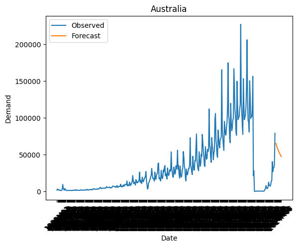

```
Japan
```

|  | model_label | destination | mae | mase | mape | denominator | n_denominator_pairs |
| --- | --- | --- | --- | --- | --- | --- | --- |
| 5 | naive_lag1 | Japan | 131881.200000 | 4.753255 | 72.586105 | 27745.450479 | 313 |
| 25 | naive_lag12 | Japan | 152226.600000 | 5.486543 | 88.305961 | 27745.450479 | 313 |
| 49 | arima | Japan | 55188.561495 | 1.989103 | 32.877418 | 27745.450479 | 313 |

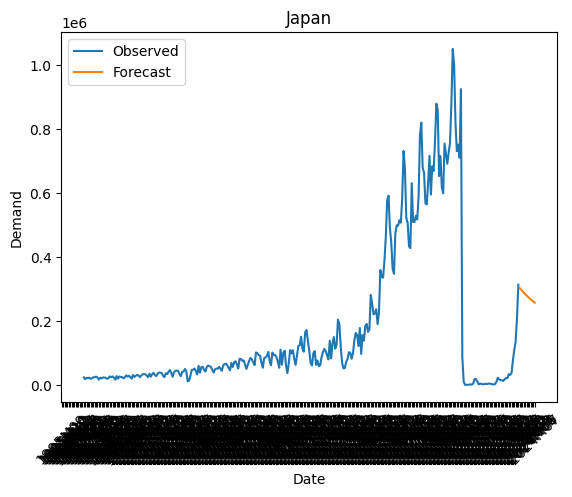

```
Canada
```

|  | model_label | destination | mae | mase | mape | denominator | n_denominator_pairs |
| --- | --- | --- | --- | --- | --- | --- | --- |
| 0 | naive_lag1 | Canada | 8453.400000 | 1.353923 | 44.825228 | 6243.636364 | 253 |
| 20 | naive_lag12 | Canada | 12072.200000 | 1.933521 | 72.313340 | 6243.636364 | 253 |
| 43 | arima | Canada | 1512.207503 | 0.242200 | 9.686251 | 6243.636364 | 253 |

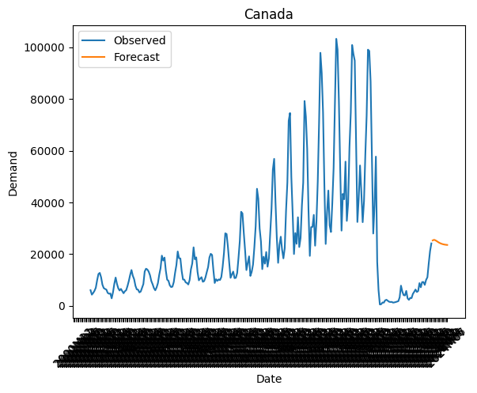

```
Hong Kong China
```

|  | model_label | destination | mae | mase | mape | denominator | n_denominator_pairs |
| --- | --- | --- | --- | --- | --- | --- | --- |
| 4 | naive_lag1 | Hong Kong China | 1.229352e+06 | 5.208431 | 51.651148 | 236031.183391 | 289 |
| 24 | naive_lag12 | Hong Kong China | 2.320349e+06 | 9.830690 | 99.235183 | 236031.183391 | 289 |
| 47 | arima | Hong Kong China | 5.170750e+05 | 2.190706 | 22.485327 | 236031.183391 | 289 |

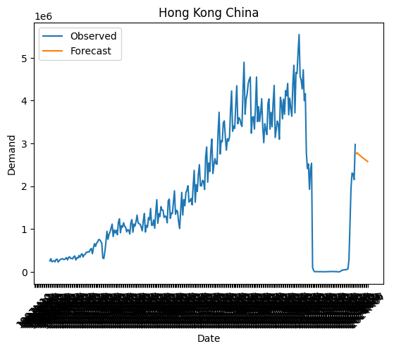

```python
selected_markets = ["Australia", "Japan", "Canada", "Hong Kong China"]

for market in selected_markets:
  print(market)

  # Validation results
  display(validation_metrics[validation_metrics["destination"] == market][[
      "model_label", "destination", "mae", "mase", "mape", "denominator",
      "n_denominator_pairs"]])

  # Historical demand and final forecast
  historical = raw_tourism_data[["Date", market]].copy()
  forecast = forecast_submission_wide[["Date", market]].copy()

  plt.plot(historical["Date"], historical[market], label="Observed")
  plt.plot(forecast["Date"], forecast[market], label="Forecast")
  plt.title(f"{market}")
  plt.xlabel("Date")
  plt.ylabel("Demand")
  plt.legend()
  plt.xticks(rotation=45)
  plt.show()
```

## Part III: Group video and collaboration presentation

### Question 7: Group video and collaboration explanation [15 marks]

Submit an 8-12 minute group video according to the CloudDeakin Assignment requirements. Every group member should participate unless the unit chair has approved an alternative arrangement. The video must show code execution, identify the submitted forecast CSV, explain how the CSV can be regenerated from `forecast_submission_wide`, and let each member explain a meaningful part of the submitted work.

**Required answer markers:** Do not delete, rename, edit, move, or reorder the Q7 START/END marker comments below. Write your response between them.

## Dataset and external source acknowledgement

Acknowledge the TULIP Lab `ISF-TDF2023` dataset and every external source used by your group. Include source URLs or citations, retrieval dates where relevant, and cutoff evidence.

Dataset acknowledgement to include or adapt:

```
Dataset: ISF-TDF2023.
Publisher: TULIP Lab.
Repository: TULIP Lab Open Data Repository, https://github.com/tulip-lab/open-data.
Licence: CC BY 4.0 unless otherwise stated.
Suggested attribution: TULIP Lab. TULIP Lab Open Data Repository. https://github.com/tulip-lab/open-data. Licensed under CC BY 4.0. Also cite Zhang, Song, Li, Law, and Li (2026).
Associated publication: Zhang, Yishuo; Song, Baobao; Li, Xin; Law, Rob; Li, Gang (2026). Imputation recovery tourism demand forecasting. Annals of Tourism Research, 118, Article 104144. https://doi.org/10.1016/j.annals.2026.104144.
```

## Submission checklist

Before submitting, check that:

- `GROUP_INFO` is complete and required headings/functions/objects/answer markers are preserved.
- The A2 Forecast Measures Guide has been used for MASE/MAPE handling.
- `None` placeholders have been replaced with completed objects, displayed outputs, or concise evidence summaries.
- The notebook runs top to bottom in a clean runtime and can regenerate the final CSV.
- Random seeds or controlled stochastic behaviour are documented where relevant.
- The PDF includes relevant outputs, figures, tables, and explanations.
- Q1 returns a DataFrame with the required row and column order.
- Q2 returns a dictionary with every key in `Q2_AUDIT_FIELDS` and the required forecast-only `None` values.
- Q3 returns `(destination_metrics, aggregate_metrics)` using `DESTINATION_METRIC_COLUMNS` and `AGGREGATE_METRIC_FIELDS`.
- `baseline_validation_comparison` includes both baselines, all 20 destinations, required measure columns, denominator diagnostics, and row counts.
- `baseline_validation_summary` includes aggregate measures for both baselines.
- `validation_forecasts`, `validation_metrics`, and `model_summary` use their required minimum columns and cover the required models.
- `model_summary` contains exactly one `selected=True` row.
- `forecast_submission_wide` has one `Date` column, exactly 20 destination columns, and exactly 12 rows for `2023M08` to `2024M07`.
- `forecast_submission_audit` contains every Q2 audit key, uses `can_align=None`, and reports `is_valid=True` before export.
- The final forecast CSV is exported directly from `forecast_submission_wide` with `index=False` and no manual post-export edits.
- Forecast values are numeric, finite, destination-specific, and not placeholders or copied actual/result values.
- External data sources are cited, cutoff-safe, and included in `external_data/` where required and permitted.
- No credentials, private data, private paths, or restricted links are included.
- The group video and any contribution material follow CloudDeakin instructions.